# Environmental and local habitat variables as predictors of trophic interactions in subtidal rocky reefs along the SE Pacific coast

#### 2) Crabs 24h

*a.* Analyses

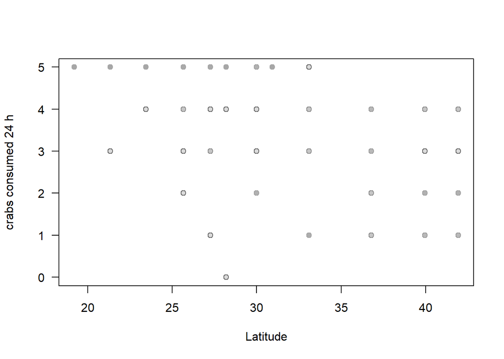

```r
# First, examine a simple scatter plot (always a good idea!)
   plot(C_24$Latitude, C_24$Consumed_individuals, xlab = "Latitude", ylab = "crabs consumed 24 h", las=1)
   mygrey <- grey(level = 0.65, alpha = 0.4)
   points(C_24$Latitude, C_24$Consumed_individuals, pch = 21, col = mygrey, bg = mygrey)
```

```r
C24_mod1 <- mgcv::gam(Consumed_individuals ~ s(Latitude, k=11), gamma=1.4, data = C_24, family =poisson())
C24_mod2 <- mgcv::gam(Consumed_individuals ~ s(Latitude, k=11), gamma=1.4, data = C_24, family =nb())
```

```r
AICc(C24_mod1, C24_mod2)
```

```
##                df     AICc
## C24_mod1 2.098819 433.6553
## C24_mod2 3.302821 436.0297
```

```r
summary(C24_mod1)
```

```
##
## Family: poisson
## Link function: log
##
## Formula:
## Consumed_individuals ~ s(Latitude, k = 11)
##
## Parametric coefficients:
##             Estimate Std. Error z value Pr(>|z|)
## (Intercept)  1.29862    0.04852   26.76   <2e-16 ***
## ---
## Signif. codes:  0 '***' 0.001 '**' 0.01 '*' 0.05 '.' 0.1 ' ' 1
##
## Approximate significance of smooth terms:
##               edf Ref.df Chi.sq  p-value
## s(Latitude) 1.099   1.19  29.66 9.54e-07 ***
## ---
## Signif. codes:  0 '***' 0.001 '**' 0.01 '*' 0.05 '.' 0.1 ' ' 1
##
## R-sq.(adj) =  0.385   Deviance explained = 34.2%
## UBRE = -0.46791  Scale est. = 1         n = 120
```

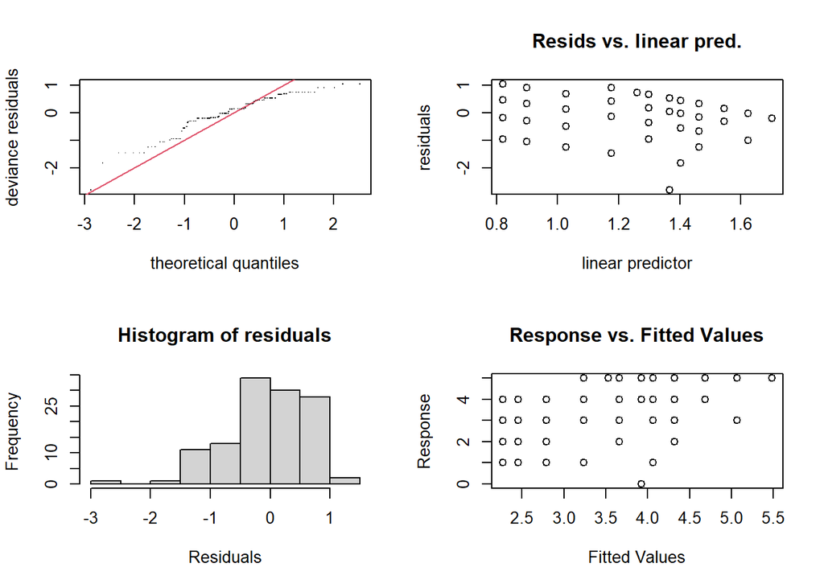

```
##
## Method: UBRE   Optimizer: outer newton
## full convergence after 5 iterations.
## Gradient range [-3.566326e-08,-3.566326e-08]
## (score -0.467908 & scale 1).
## Hessian positive definite, eigenvalue range [0.0002048148,0.0002048148].
## Model rank =  11 / 11
##
## Basis dimension (k) checking results. Low p-value (k-index<1) may
## indicate that k is too low, especially if edf is close to k'.
##
##               k'  edf k-index p-value
## s(Latitude) 10.0  1.1    0.84    0.03 *
## ---
## Signif. codes:  0 '***' 0.001 '**' 0.01 '*' 0.05 '.' 0.1 ' ' 1
```

```r
par(mfrow = c(2, 2))
gam.check(C24_mod1)
```

Calculate predictions for Crab consumption after 2 and 24 h

```r
#create a new dataframe: names should match those of the original dataframe
newdfr = expand.grid(Latitude = rep(seq(from = min(C_2$Latitude), to = max(C_2$Latitude), length.out = 100), 5))

#Crabs 2h

dat1 <- predict(C2_mod1, newdata = newdfr, type = "link", se.fit = TRUE)
critval <- 1.96 ## approx 95% CI
upr <- dat1$fit + (critval * dat1$se.fit)
lwr <- dat1$fit - (critval * dat1$se.fit)
fit <- dat1$fit
fit2 <- C2_mod1$family$linkinv(fit)
upr2 <- C2_mod1$family$linkinv(upr)
lwr2 <- C2_mod1$family$linkinv(lwr)

newdfr$lwr <- lwr2
newdfr$upr <- upr2
newdfr$fit <- fit2

#For crabs 24 h

newdfr24 = expand.grid(Latitude = rep(seq(from = min(C_24$Latitude), to = max(C_24$Latitude), length.out = 100), 5))

dat2 <- predict(C24_mod1, newdata = newdfr24, type = "link", se.fit = TRUE)
upr1 <- dat2$fit + (critval * dat2$se.fit)
lwr1 <- dat2$fit - (critval * dat2$se.fit)
fit1 <- dat2$fit
fit3 <- C24_mod1$family$linkinv(fit1)
upr3 <- C24_mod1$family$linkinv(upr1)
lwr3 <- C24_mod1$family$linkinv(lwr1)

newdfr24$lwr <- lwr3
newdfr24$upr <- upr3
newdfr24$fit <- fit3
```

Add new column to mix datasets

```r
newdfr$Assay_time <- "2 h"
newdfr24$Assay_time <- "24 h"
C_2$Assay_time <- "2 h"
C_24$Assay_time <- "24 h"

#Bind datasets

total <- rbind(newdfr, newdfr24)

total2 <- rbind (C_2, C_24)
```

#### **3)** Crabs 2 and 24 h prediction plot

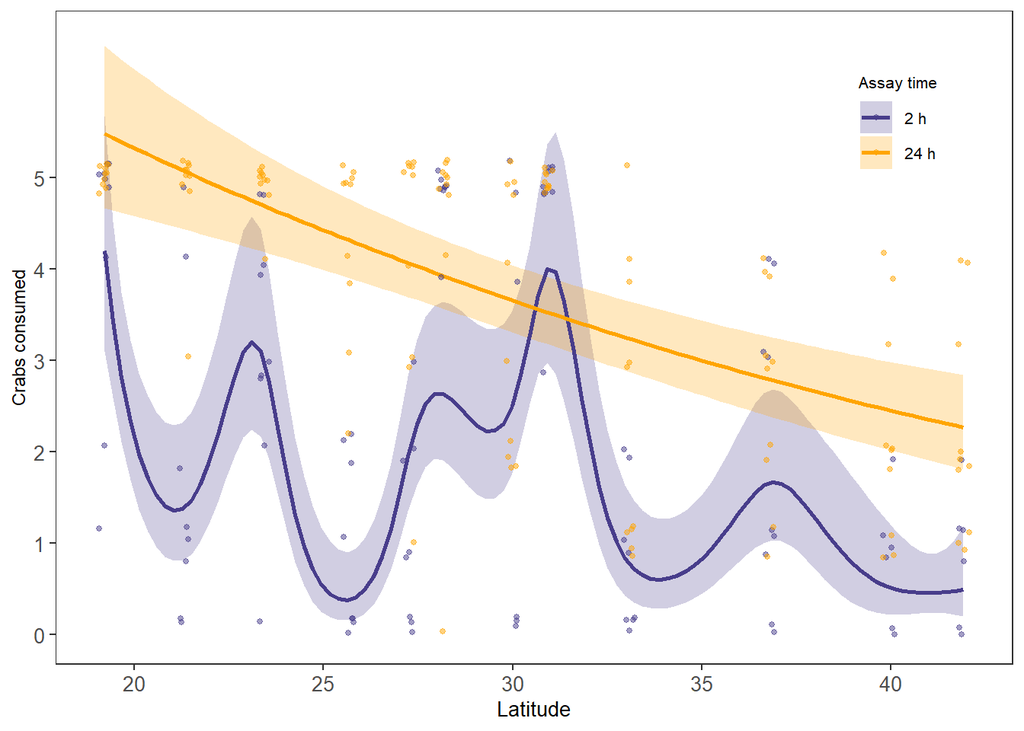

```r
ggplot()+
  geom_ribbon(data = total, aes(x = Latitude, y = fit, ymin = lwr, ymax = upr, group = Assay_time, fill = Assay_time ), alpha = .25)  +
  geom_line(data = total, aes(x = Latitude, y = fit, color = Assay_time, group = Assay_time), size = 1) +
  geom_jitter(data = total2, aes(x= Latitude, y=Consumed_individuals, color =Assay_time), width=0.15, height = 0.2, size = 1, alpha = 0.5)+
  labs(x = "Latitude", y = "Crabs consumed")  + Theme1 +
  scale_color_manual("Assay time",values=c("darkslateblue", "orange1"))+
   scale_fill_manual("Assay time", values=c("darkslateblue", "orange1")) +
  theme(legend.position = c(0.88, 0.83),legend.title = element_text(size = 8),
               legend.text = element_text(size = 8)) +
  scale_x_continuous(breaks = seq(15, 40, 5)) +
  scale_y_continuous(limits = c(0,6.5), breaks = seq(0, 5, 1))
```

```r
ggsave("Crabs.jpeg", units="mm", width=120, height=75, dpi=300)
```

#### 4) Squidpops 2h

*a.* Analyses

```r
S2_mod1 <- mgcv::gam(Consumed_individuals ~ s(Latitude, k=10), gamma=1.4, data = S_2, family =poisson())
S2_mod2 <- mgcv::gam(Consumed_individuals ~ s(Latitude, k=10), gamma=1.4, S_2, family =nb())
```

```r
AICc(S2_mod2, S2_mod1)
```

```
##               df     AICc
## S2_mod2 3.001418 490.8237
## S2_mod1 9.825399 462.7014
```

```r
summary(S2_mod1)
```

```
##
## Family: poisson
## Link function: log
##
## Formula:
## Consumed_individuals ~ s(Latitude, k = 10)
##
## Parametric coefficients:
##             Estimate Std. Error z value Pr(>|z|)
## (Intercept)  0.72206    0.06967   10.36   <2e-16 ***
## ---
## Signif. codes:  0 '***' 0.001 '**' 0.01 '*' 0.05 '.' 0.1 ' ' 1
##
## Approximate significance of smooth terms:
##               edf Ref.df Chi.sq p-value
## s(Latitude) 8.825  8.989  50.88  <2e-16 ***
## ---
## Signif. codes:  0 '***' 0.001 '**' 0.01 '*' 0.05 '.' 0.1 ' ' 1
##
## R-sq.(adj) =  0.209   Deviance explained = 27.2%
## UBRE = 0.77145  Scale est. = 1         n = 120
```

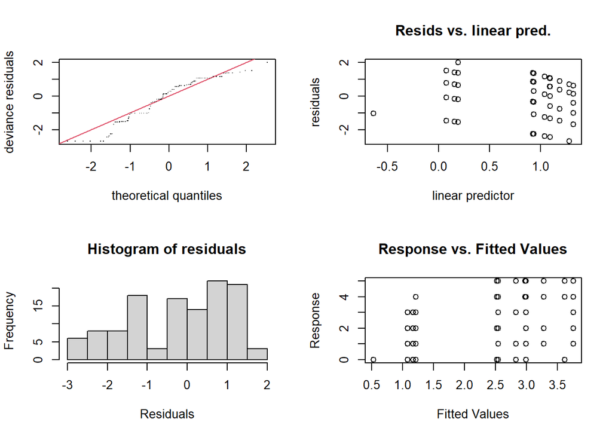

```
##
## Method: UBRE   Optimizer: outer newton
## full convergence after 6 iterations.
## Gradient range [1.464168e-06,1.464168e-06]
## (score 0.7714456 & scale 1).
## Hessian positive definite, eigenvalue range [0.003165155,0.003165155].
## Model rank =  10 / 10
##
## Basis dimension (k) checking results. Low p-value (k-index<1) may
## indicate that k is too low, especially if edf is close to k'.
##
##               k'  edf k-index p-value
## s(Latitude) 9.00 8.83    0.56  <2e-16 ***
## ---
## Signif. codes:  0 '***' 0.001 '**' 0.01 '*' 0.05 '.' 0.1 ' ' 1
```

```r
par(mfrow = c(2, 2))
gam.check(S2_mod1)
```

#### 5) Squidpops 24h

*a.* Analyses

```r
S24_mod1 <- mgcv::gam(Consumed_individuals ~ s(Latitude, k=10), gamma=1.4, data = S_24, family =poisson())
S24_mod2 <- mgcv::gam(Consumed_individuals ~ s(Latitude, k=10), gamma=1.4, S_24, family =nb())
```

```r
AICc(S24_mod2, S24_mod1)
```

```
##                df     AICc
## S24_mod2 3.000007 448.2412
## S24_mod1 2.000015 446.1367
```

```r
summary(S24_mod1)
```

```
##
## Family: poisson
## Link function: log
##
## Formula:
## Consumed_individuals ~ s(Latitude, k = 10)
##
## Parametric coefficients:
##             Estimate Std. Error z value Pr(>|z|)
## (Intercept)  1.43953    0.04461   32.27   <2e-16 ***
## ---
## Signif. codes:  0 '***' 0.001 '**' 0.01 '*' 0.05 '.' 0.1 ' ' 1
##
## Approximate significance of smooth terms:
##             edf Ref.df Chi.sq p-value
## s(Latitude)   1      1   7.33 0.00678 **
## ---
## Signif. codes:  0 '***' 0.001 '**' 0.01 '*' 0.05 '.' 0.1 ' ' 1
##
## R-sq.(adj) =  0.154   Deviance explained = 12.1%
## UBRE = -0.501  Scale est. = 1         n = 120
```

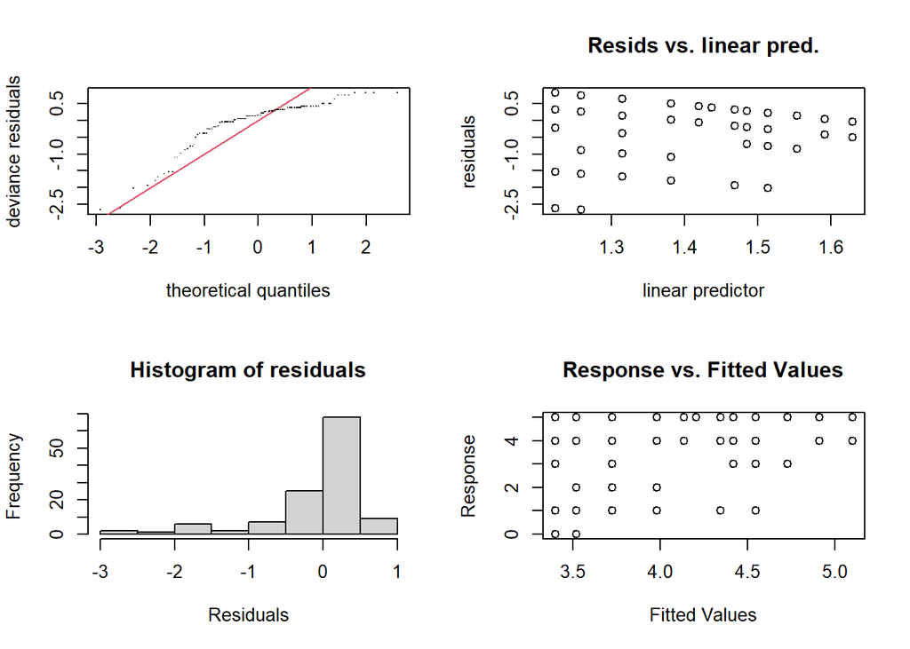

```
##
## Method: UBRE   Optimizer: outer newton
## full convergence after 10 iterations.
## Gradient range [-2.01421e-07,-2.01421e-07]
## (score -0.5009978 & scale 1).
## Hessian positive definite, eigenvalue range [2.014182e-07,2.014182e-07].
## Model rank =  10 / 10
##
## Basis dimension (k) checking results. Low p-value (k-index<1) may
## indicate that k is too low, especially if edf is close to k'.
##
##             k' edf k-index p-value
## s(Latitude)  9   1    0.75  <2e-16 ***
## ---
## Signif. codes:  0 '***' 0.001 '**' 0.01 '*' 0.05 '.' 0.1 ' ' 1
```

```r
par(mfrow = c(2, 2))
gam.check(S24_mod1)
```

```r
#For squidpops 24 h

newdata_S24 <- data.frame(Latitude = rep(seq(from = min(S_24$Latitude), to = max(S_24$Latitude), length.out = 100), 5))

#add preditions
dat3 <- predict(S24_mod1, newdata = newdata_S24, type = "link", se.fit = TRUE)
upr1 <- dat3$fit + (critval * dat3$se.fit)
lwr1<- dat3$fit - (critval * dat3$se.fit)
fit1 <- dat3$fit
fit2 <- S24_mod1$family$linkinv(fit1)
upr2 <- S24_mod1$family$linkinv(upr1)
lwr2 <- S24_mod1$family$linkinv(lwr1)

newdata_S24$lwr <- lwr2
newdata_S24$upr <- upr2
newdata_S24$fit <- fit2

#For squidpops 24 h

newdata_S2 <- data.frame(Latitude = rep(seq(from = min(S_2$Latitude), to = max(S_2$Latitude), length.out = 100), 5))

#add preditions
dat4 <- predict(S2_mod1, newdata = newdata_S24, type = "link", se.fit = TRUE)
upr4 <- dat4$fit + (critval * dat4$se.fit)
lwr4<- dat4$fit - (critval * dat4$se.fit)
fit4 <- dat4$fit
fit5 <- S2_mod1$family$linkinv(fit4)
upr5 <- S2_mod1$family$linkinv(upr4)
lwr5 <- S2_mod1$family$linkinv(lwr4)

newdata_S2$lwr <- lwr5
newdata_S2$upr <- upr5
newdata_S2$fit <- fit5
```

Add new column to mix datasets

```r
S_2$Assay_time <- "2 h"
S_24$Assay_time <- "24 h"
newdata_S24$Assay_time <- "24 h"
newdata_S2$Assay_time <- "2 h"
##Keep only colums for plotting
total <- rbind (newdata_S2, newdata_S24)
total2 <- rbind (S_2, S_24)
```

#### **3)** Squidpops 2 and 24 h prediction plot

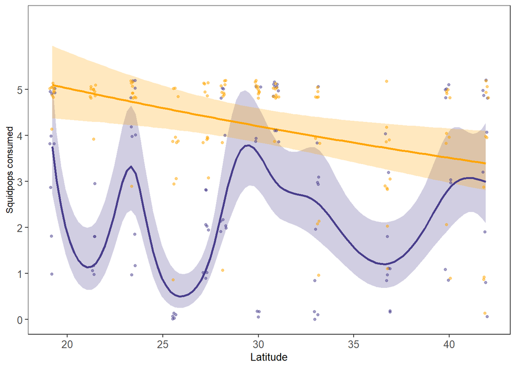

```r
ggplot() +
  geom_ribbon(data = total, aes(x = Latitude, y = fit, ymin = lwr, ymax = upr, group = Assay_time, fill = Assay_time ), alpha = .25) +
  geom_line(data = total, aes(x = Latitude, y = fit, color = Assay_time, group = Assay_time ), size = 1) +
  geom_jitter(data = total2, aes(x= Latitude, y=Consumed_individuals, color =Assay_time), width=0.15, height = 0.2, size = 1, alpha = .5)+
  labs(x = "Latitude", y = "Squidpops consumed")  + Theme1 +
  scale_color_manual("Assay time",values=c("darkslateblue", "orange1"))+
   scale_fill_manual("Assay time", values=c("darkslateblue", "orange1")) +
  theme(legend.position = "none") +
  scale_x_continuous(breaks = seq(15, 40, 5)) +
  scale_y_continuous(limits = c(0,6.5), breaks = seq(0, 5, 1))
```

```r
ggsave("Squidpops.jpeg", units="mm", width=120, height=70, dpi=300)
```

### **4b):** Herbivory vs latitude

```r
Herbivory_env$Latitude <- Herbivory_env$Latitude*-1
```

*a.* Analyses

```r
Herb_mod1 <- mgcv::gam(Consumed_proportion ~ s(Latitude), data = Herbivory_env, family =binomial())
Herb_mod2 <- mgcv::gam(Consumed_proportion ~ s(Latitude), data = Herbivory_env, family =quasibinomial())
```

```r
AICc(Herb_mod2, Herb_mod1)
```

```
##                  df     AICc
## Herb_mod2 10.863328       NA
## Herb_mod1  9.759176 413.4238
```

```r
summary(Herb_mod1)
```

```
##
## Family: binomial
## Link function: logit
##
## Formula:
## Consumed_proportion ~ s(Latitude)
##
## Parametric coefficients:
##             Estimate Std. Error z value Pr(>|z|)
## (Intercept)  -3.1503     0.5485  -5.743 9.29e-09 ***
## ---
## Signif. codes:  0 '***' 0.001 '**' 0.01 '*' 0.05 '.' 0.1 ' ' 1
##
## Approximate significance of smooth terms:
##               edf Ref.df Chi.sq p-value
## s(Latitude) 8.759  8.977  81.65  <2e-16 ***
## ---
## Signif. codes:  0 '***' 0.001 '**' 0.01 '*' 0.05 '.' 0.1 ' ' 1
##
## R-sq.(adj) =  0.451   Deviance explained = 46.4%
## UBRE = -0.52027  Scale est. = 1         n = 590
```

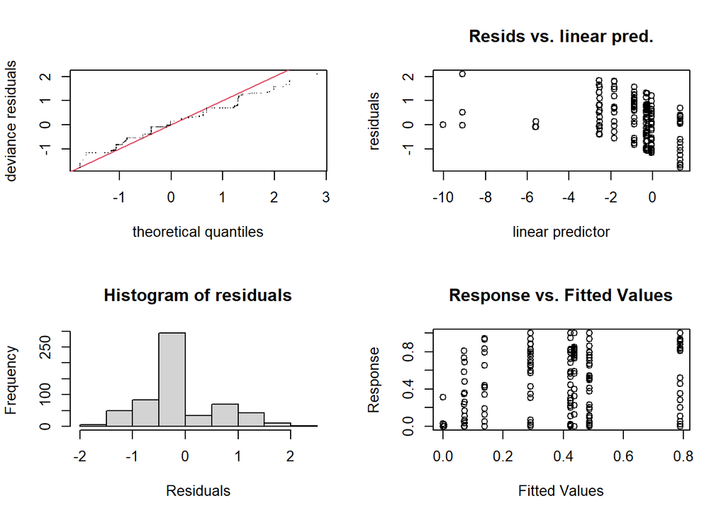

```
##
## Method: UBRE   Optimizer: outer newton
## full convergence after 8 iterations.
## Gradient range [5.631959e-09,5.631959e-09]
## (score -0.5202735 & scale 1).
## Hessian positive definite, eigenvalue range [0.000357682,0.000357682].
## Model rank =  10 / 10
##
## Basis dimension (k) checking results. Low p-value (k-index<1) may
## indicate that k is too low, especially if edf is close to k'.
##
##               k'  edf k-index p-value
## s(Latitude) 9.00 8.76    0.46  <2e-16 ***
## ---
## Signif. codes:  0 '***' 0.001 '**' 0.01 '*' 0.05 '.' 0.1 ' ' 1
```

```r
par(mfrow = c(2, 2))
gam.check(Herb_mod1)
```

```r
#For squidpops 24 h

newdata_H <- data.frame(Latitude = rep(seq(from = min(Herbivory_env$Latitude), to = max(Herbivory_env$Latitude), length.out = 100), 5))

#add preditions
dat3 <- predict(Herb_mod1, newdata = newdata_H, type = "link", se.fit = TRUE)
upr1 <- dat3$fit + (critval * dat3$se.fit)
lwr1<- dat3$fit - (critval * dat3$se.fit)
fit1 <- dat3$fit
fit2 <- Herb_mod1$family$linkinv(fit1)
upr2 <- Herb_mod1$family$linkinv(upr1)
lwr2 <- Herb_mod1$family$linkinv(lwr1)

newdata_H$lwr <- lwr2
newdata_H$upr <- upr2
newdata_H$fit <- fit2
```

*b.* Plot predicted relationship

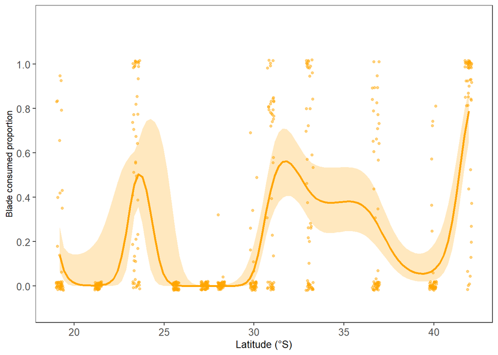

```r
ggplot() +
  geom_ribbon(data = newdata_H, aes(x = Latitude, y = fit, ymin = lwr, ymax = upr), alpha = .25, fill = "orange1") +
  geom_line(data = newdata_H, aes(x = Latitude, y = fit ), size = 1, color = "orange1") +
  geom_jitter(data = Herbivory_env, aes(x= Latitude, y=Consumed_proportion), color = "orange1", width=0.2, height = 0.02, size = 1, alpha = .5)+
  labs(x = "Latitude (°S)", y = "Blade consumed proportion")  + Theme1  +
  theme(legend.position = "none") +
  scale_x_continuous(breaks = seq(15, 40, 5)) +
  scale_y_continuous(limits = c(-0.1,1.2), breaks = seq(0, 1, 0.2))
```

```r
ggsave("Seaweed24.jpeg", units="mm", width=120, height=75, dpi=300)
```

## **Part 5:** Predation intensity: Effect of site-specific variables

Here, the individual effects of each predictor will be tested.

1. First, create datasets to be used in the analysis

```r
Predation_analysis <- Predation_6 %>%
  dplyr::select(-Rope, -Bait, -Camera, -Assay_time, -Initial_Individuals, -Remaining_individuals, -Survival_proportion,-Consumed_proportion)

#Separate by Bait and Assay time

Crabs_24 <- filter(Predation_analysis, Bait2 == "Crabs" & Assay_time2 == 24)
Crabs_2 <- filter(Predation_analysis, Bait2 == "Crabs" & Assay_time2 == 2)
Squidpops_24 <- filter(Predation_analysis, Bait2 == "Squidpops" & Assay_time2 == 24)
Squidpops_2 <- filter(Predation_analysis, Bait2 == "Squidpops" & Assay_time2 == 2)
```

### **5a):** Standardisation and test autocorrelation

**1)** Standardise

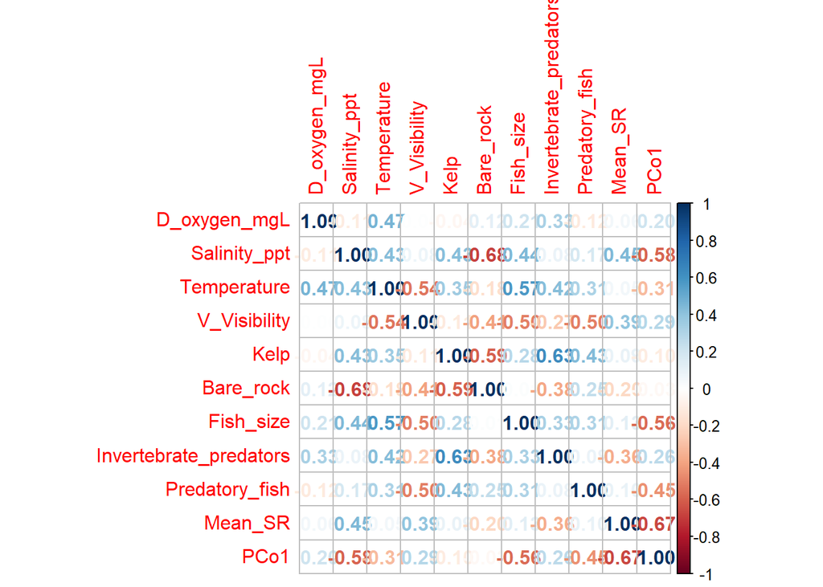

```r
#Crabs 24h
Crabs24_num <- Crabs_24 %>%
  dplyr::select(-Site, -Bait2, -Assay_time2, -Consumed_individuals, -Latitude, -Day_length)
Crabs24_stand <- decostand(Crabs24_num, method="range", na.rm = TRUE)
#Test autocorrelation
corrplot(cor(Crabs24_stand), method = "number")
```

```r
#Add site and consumed individuals for analyses
Crabs24_stand$Site <- Crabs_24$Site
Crabs24_stand$Consumed_individuals<- Crabs_24$Consumed_individuals
Crabs24_stand$Latitude<- Crabs_24$Latitude
```

*No multicolinearity found*

Standardise all final variables to be in a range 0-1

```r
#Crabs 2h
Crabs2_num <- Crabs_2 %>%
  dplyr::select(-Site, -Bait2, -Assay_time2, -Consumed_individuals, -Latitude)
Crabs2_stand <- decostand(Crabs2_num, method="range", na.rm = TRUE)
Crabs2_stand$Site <- Crabs_2$Site
Crabs2_stand$Consumed_individuals<- Crabs_2$Consumed_individuals
Crabs2_stand$Latitude<- Crabs_2$Latitude
#Squidpops 24h
Squidpops24_num <- Squidpops_24 %>%
  dplyr::select(-Site, -Bait2, -Assay_time2, -Consumed_individuals, -Latitude)
Squidpops24_stand <- decostand(Squidpops24_num, method="range", na.rm = TRUE)
Squidpops24_stand$Site <- Squidpops_24$Site
Squidpops24_stand$Consumed_individuals<- Squidpops_24$Consumed_individuals
Squidpops24_stand$Latitude<- Squidpops_24$Latitude
#Squidpops 2h
Squidpops2_num <- Squidpops_2 %>%
  dplyr::select(-Site, -Bait2, -Assay_time2, -Consumed_individuals, -Latitude)
Squidpops2_stand <- decostand(Squidpops2_num, method="range", na.rm = TRUE)
Squidpops2_stand$Site <- Squidpops_2$Site
Squidpops2_stand$Consumed_individuals<- Squidpops_2$Consumed_individuals
Squidpops2_stand$Latitude<- Squidpops_2$Latitude
```

### **5b)** Model selection: Crabs 2h

1. Temperature

```r
my_glmT<- glm(Consumed_individuals~  Temperature, data=Crabs2_stand, family = poisson)
check_overdispersion(my_glmT)
```

```
## # Overdispersion test
##
##        dispersion ratio =   1.734
##   Pearson's Chi-Squared = 204.668
##                 p-value = < 0.001
```

```
## Overdispersion detected.
```

```r
my_glmT<- glm.nb(Consumed_individuals~  Temperature, data=Crabs2_stand)
check_overdispersion(my_glmT)
```

```
## # Overdispersion test
##
##  dispersion ratio = 0.666
##           p-value =  0.08
```

```
## No overdispersion detected.
```

```r
summary(my_glmT)
```

```
##
## Call:
## glm.nb(formula = Consumed_individuals ~ Temperature, data = Crabs2_stand,
##     init.theta = 1.804741369, link = log)
##
## Coefficients:
##             Estimate Std. Error z value Pr(>|z|)
## (Intercept)  -0.7265     0.2970  -2.446   0.0144 *
## Temperature   1.9321     0.3861   5.003 5.63e-07 ***
## ---
## Signif. codes:  0 '***' 0.001 '**' 0.01 '*' 0.05 '.' 0.1 ' ' 1
##
## (Dispersion parameter for Negative Binomial(1.8047) family taken to be 1)
##
##     Null deviance: 173.79  on 119  degrees of freedom
## Residual deviance: 143.22  on 118  degrees of freedom
## AIC: 435.29
##
## Number of Fisher Scoring iterations: 1
##
##
##               Theta:  1.805
##           Std. Err.:  0.633
##
##  2 x log-likelihood:  -429.289
```

```r
AICc(my_glmT)
```

```
## [1] 435.4963
```

2. Salinity

```r
my_glmSC2<- glm(Consumed_individuals~  Salinity_ppt, data=Crabs2_stand, family = poisson)
check_overdispersion(my_glmSC2)
```

```
## # Overdispersion test
##
##        dispersion ratio =   2.003
##   Pearson's Chi-Squared = 236.411
##                 p-value = < 0.001
```

```
## Overdispersion detected.
```

```r
my_glmSC2<- glm.nb(Consumed_individuals~  Salinity_ppt, data=Crabs2_stand)
check_overdispersion(my_glmSC2)
```

```
## # Overdispersion test
##
##  dispersion ratio = 0.702
##           p-value = 0.184
```

```
## No overdispersion detected.
```

```r
summary(my_glmSC2)
```

```
##
## Call:
## glm.nb(formula = Consumed_individuals ~ Salinity_ppt, data = Crabs2_stand,
##     init.theta = 1.09232541, link = log)
##
## Coefficients:
##              Estimate Std. Error z value Pr(>|z|)
## (Intercept)   -0.4038     0.3777  -1.069  0.28507
## Salinity_ppt   1.5256     0.5117   2.982  0.00287 **
## ---
## Signif. codes:  0 '***' 0.001 '**' 0.01 '*' 0.05 '.' 0.1 ' ' 1
##
## (Dispersion parameter for Negative Binomial(1.0923) family taken to be 1)
##
##     Null deviance: 141.19  on 119  degrees of freedom
## Residual deviance: 133.24  on 118  degrees of freedom
## AIC: 452.5
##
## Number of Fisher Scoring iterations: 1
##
##
##               Theta:  1.092
##           Std. Err.:  0.282
##
##  2 x log-likelihood:  -446.499
```

```r
AICc(my_glmSC2)
```

```
## [1] 452.7059
```

3. Dissolved oxygen

```r
my_glmOx<- glm.nb(Consumed_individuals~  D_oxygen_mgL, data=Crabs2_stand)
summary(my_glmOx)
```

```
##
## Call:
## glm.nb(formula = Consumed_individuals ~ D_oxygen_mgL, data = Crabs2_stand,
##     init.theta = 1.455072917, link = log)
##
## Coefficients:
##              Estimate Std. Error z value Pr(>|z|)
## (Intercept)   -0.0611     0.1946  -0.314    0.754
## D_oxygen_mgL   1.4488     0.3371   4.298 1.72e-05 ***
## ---
## Signif. codes:  0 '***' 0.001 '**' 0.01 '*' 0.05 '.' 0.1 ' ' 1
##
## (Dispersion parameter for Negative Binomial(1.4551) family taken to be 1)
##
##     Null deviance: 159.78  on 119  degrees of freedom
## Residual deviance: 139.58  on 118  degrees of freedom
## AIC: 442.61
##
## Number of Fisher Scoring iterations: 1
##
##
##               Theta:  1.455
##           Std. Err.:  0.452
##
##  2 x log-likelihood:  -436.609
```

```r
AICc(my_glmOx)
```

```
## [1] 442.8161
```

4. Visibility

```r
my_glm<- glm.nb(Consumed_individuals~ V_Visibility, data=Crabs2_stand)
summary(my_glm)
```

```
##
## Call:
## glm.nb(formula = Consumed_individuals ~ V_Visibility, data = Crabs2_stand,
##     init.theta = 0.9594356772, link = log)
##
## Coefficients:
##              Estimate Std. Error z value Pr(>|z|)
## (Intercept)    0.5989     0.2140   2.799  0.00512 **
## V_Visibility   0.1710     0.4245   0.403  0.68703
## ---
## Signif. codes:  0 '***' 0.001 '**' 0.01 '*' 0.05 '.' 0.1 ' ' 1
##
## (Dispersion parameter for Negative Binomial(0.9594) family taken to be 1)
##
##     Null deviance: 132.93  on 119  degrees of freedom
## Residual deviance: 132.79  on 118  degrees of freedom
## AIC: 460.03
##
## Number of Fisher Scoring iterations: 1
##
##
##               Theta:  0.959
##           Std. Err.:  0.235
##
##  2 x log-likelihood:  -454.031
```

```r
AICc(my_glm)
```

```
## [1] 460.2381
```

5. Community composition

```r
my_glm<- glm.nb(Consumed_individuals~  PCo1, data=Crabs2_stand)
summary(my_glm)
```

```
##
## Call:
## glm.nb(formula = Consumed_individuals ~ PCo1, data = Crabs2_stand,
##     init.theta = 0.9572416306, link = log)
##
## Coefficients:
##             Estimate Std. Error z value Pr(>|z|)
## (Intercept)  0.68732    0.16118   4.264 2.01e-05 ***
## PCo1        -0.04288    0.32097  -0.134    0.894
## ---
## Signif. codes:  0 '***' 0.001 '**' 0.01 '*' 0.05 '.' 0.1 ' ' 1
##
## (Dispersion parameter for Negative Binomial(0.9572) family taken to be 1)
##
##     Null deviance: 132.79  on 119  degrees of freedom
## Residual deviance: 132.77  on 118  degrees of freedom
## AIC: 460.15
##
## Number of Fisher Scoring iterations: 1
##
##
##               Theta:  0.957
##           Std. Err.:  0.235
##
##  2 x log-likelihood:  -454.154
```

```r
AICc(my_glm)
```

```
## [1] 460.3613
```

6. Kelp Cover

```r
my_glm<- glm.nb(Consumed_individuals~ Kelp, data=Crabs2_stand)
summary(my_glm)
```

```
##
## Call:
## glm.nb(formula = Consumed_individuals ~ Kelp, data = Crabs2_stand,
##     init.theta = 1.175060865, link = log)
##
## Coefficients:
##             Estimate Std. Error z value Pr(>|z|)
## (Intercept)   0.3118     0.1547   2.015  0.04389 *
## Kelp          1.1196     0.3639   3.077  0.00209 **
## ---
## Signif. codes:  0 '***' 0.001 '**' 0.01 '*' 0.05 '.' 0.1 ' ' 1
##
## (Dispersion parameter for Negative Binomial(1.1751) family taken to be 1)
##
##     Null deviance: 145.89  on 119  degrees of freedom
## Residual deviance: 135.96  on 118  degrees of freedom
## AIC: 450.9
##
## Number of Fisher Scoring iterations: 1
##
##
##               Theta:  1.175
##           Std. Err.:  0.321
##
##  2 x log-likelihood:  -444.902
```

```r
AICc(my_glm)
```

```
## [1] 451.1094
```

7. Bare rock cover

```r
my_glmBR<- glm.nb(Consumed_individuals~ Bare_rock, data=Crabs2_stand)
summary(my_glmBR)
```

```
##
## Call:
## glm.nb(formula = Consumed_individuals ~ Bare_rock, data = Crabs2_stand,
##     init.theta = 1.228290388, link = log)
##
## Coefficients:
##             Estimate Std. Error z value Pr(>|z|)
## (Intercept)   1.1046     0.1536   7.190 6.48e-13 ***
## Bare_rock    -1.3545     0.3449  -3.927 8.58e-05 ***
## ---
## Signif. codes:  0 '***' 0.001 '**' 0.01 '*' 0.05 '.' 0.1 ' ' 1
##
## (Dispersion parameter for Negative Binomial(1.2283) family taken to be 1)
##
##     Null deviance: 148.76  on 119  degrees of freedom
## Residual deviance: 134.51  on 118  degrees of freedom
## AIC: 446.9
##
## Number of Fisher Scoring iterations: 1
##
##
##               Theta:  1.228
##           Std. Err.:  0.335
##
##  2 x log-likelihood:  -440.900
```

```r
AICc(my_glmBR)
```

```
## [1] 447.1067
```

8. Species richness

```r
my_glm<- glm.nb(Consumed_individuals~ Mean_SR, data=Crabs2_stand)
summary(my_glm)
```

```
##
## Call:
## glm.nb(formula = Consumed_individuals ~ Mean_SR, data = Crabs2_stand,
##     init.theta = 1.058830107, link = log)
##
## Coefficients:
##             Estimate Std. Error z value Pr(>|z|)
## (Intercept)   0.2469     0.2247   1.099   0.2719
## Mean_SR       0.8301     0.3910   2.123   0.0337 *
## ---
## Signif. codes:  0 '***' 0.001 '**' 0.01 '*' 0.05 '.' 0.1 ' ' 1
##
## (Dispersion parameter for Negative Binomial(1.0588) family taken to be 1)
##
##     Null deviance: 139.20  on 119  degrees of freedom
## Residual deviance: 134.34  on 118  degrees of freedom
## AIC: 455.48
##
## Number of Fisher Scoring iterations: 1
##
##
##               Theta:  1.059
##           Std. Err.:  0.274
##
##  2 x log-likelihood:  -449.479
```

```r
AICc(my_glm)
```

```
## [1] 455.6857
```

9. Invertebrate predators

```r
my_glm<- glm.nb(Consumed_individuals~ Invertebrate_predators, data=Crabs2_stand)
summary(my_glm)
```

```
##
## Call:
## glm.nb(formula = Consumed_individuals ~ Invertebrate_predators,
##     data = Crabs2_stand, init.theta = 1.184638797, link = log)
##
## Coefficients:
##                        Estimate Std. Error z value Pr(>|z|)
## (Intercept)              0.3891     0.1406   2.768  0.00564 **
## Invertebrate_predators   0.8476     0.2939   2.884  0.00393 **
## ---
## Signif. codes:  0 '***' 0.001 '**' 0.01 '*' 0.05 '.' 0.1 ' ' 1
##
## (Dispersion parameter for Negative Binomial(1.1846) family taken to be 1)
##
##     Null deviance: 146.42  on 119  degrees of freedom
## Residual deviance: 136.66  on 118  degrees of freedom
## AIC: 451.13
##
## Number of Fisher Scoring iterations: 1
##
##
##               Theta:  1.185
##           Std. Err.:  0.328
##
##  2 x log-likelihood:  -445.133
```

```r
AICc(my_glm)
```

```
## [1] 451.3399
```

10. Predatory fish abundance

```r
my_glm <- glm.nb(Consumed_individuals~ Predatory_fish, data=Crabs2_stand)
summary(my_glm)
```

```
##
## Call:
## glm.nb(formula = Consumed_individuals ~ Predatory_fish, data = Crabs2_stand,
##     init.theta = 0.975580135, link = log)
##
## Coefficients:
##                Estimate Std. Error z value Pr(>|z|)
## (Intercept)      0.5454     0.1713   3.183  0.00146 **
## Predatory_fish   0.3192     0.3293   0.969  0.33239
## ---
## Signif. codes:  0 '***' 0.001 '**' 0.01 '*' 0.05 '.' 0.1 ' ' 1
##
## (Dispersion parameter for Negative Binomial(0.9756) family taken to be 1)
##
##     Null deviance: 133.99  on 119  degrees of freedom
## Residual deviance: 133.04  on 118  degrees of freedom
## AIC: 459.23
##
## Number of Fisher Scoring iterations: 1
##
##
##               Theta:  0.976
##           Std. Err.:  0.241
##
##  2 x log-likelihood:  -453.226
```

```r
AICc(my_glm)
```

```
## [1] 459.4329
```

11. Fish size

```r
my_glm<- glm.nb(Consumed_individuals~ Fish_size, data=Crabs2_stand)
summary(my_glm)
```

```
##
## Call:
## glm.nb(formula = Consumed_individuals ~ Fish_size, data = Crabs2_stand,
##     init.theta = 0.967006894, link = log)
##
## Coefficients:
##             Estimate Std. Error z value Pr(>|z|)
## (Intercept)   0.3846     0.2900   1.326    0.185
## Fish_size     0.4582     0.4246   1.079    0.281
##
## (Dispersion parameter for Negative Binomial(0.967) family taken to be 1)
##
##     Null deviance: 133.43  on 119  degrees of freedom
## Residual deviance: 132.69  on 118  degrees of freedom
## AIC: 459.43
##
## Number of Fisher Scoring iterations: 1
##
##
##               Theta:  0.967
##           Std. Err.:  0.237
##
##  2 x log-likelihood:  -453.429
```

```r
AICc(my_glm)
```

```
## [1] 459.6363
```

- Test interaction between temperature and dissolved oxygen

```r
my_glm<- glm.nb(Consumed_individuals~ Temperature*D_oxygen_mgL, data=Crabs2_stand)
summary(my_glm)
```

```
##
## Call:
## glm.nb(formula = Consumed_individuals ~ Temperature * D_oxygen_mgL,
##     data = Crabs2_stand, init.theta = 2.355100978, link = log)
##
## Coefficients:
##                          Estimate Std. Error z value Pr(>|z|)
## (Intercept)              -0.55352    0.42946  -1.289   0.1974
## Temperature               1.15886    0.55926   2.072   0.0383 *
## D_oxygen_mgL             -0.09859    1.13581  -0.087   0.9308
## Temperature:D_oxygen_mgL  1.08330    1.25059   0.866   0.3864
## ---
## Signif. codes:  0 '***' 0.001 '**' 0.01 '*' 0.05 '.' 0.1 ' ' 1
##
## (Dispersion parameter for Negative Binomial(2.3551) family taken to be 1)
##
##     Null deviance: 190.78  on 119  degrees of freedom
## Residual deviance: 148.41  on 116  degrees of freedom
## AIC: 432.35
##
## Number of Fisher Scoring iterations: 1
##
##
##               Theta:  2.355
##           Std. Err.:  0.998
##
##  2 x log-likelihood:  -422.350
```

```r
AICc(my_glm)
```

```
## [1] 432.8764
```

### **5c)** Model selection: Crabs 24h

1. Temperature

```r
my_glmT24<- glm(Consumed_individuals~  Temperature, data=Crabs24_stand, family = poisson)
check_overdispersion(my_glmT24)
```

```
## # Overdispersion test
##
##        dispersion ratio =  0.431
##   Pearson's Chi-Squared = 50.817
##                 p-value =      1
```

```
## No overdispersion detected.
```

```r
summary(my_glmT24)
```

```
##
## Call:
## glm(formula = Consumed_individuals ~ Temperature, family = poisson,
##     data = Crabs24_stand)
##
## Coefficients:
##             Estimate Std. Error z value Pr(>|z|)
## (Intercept)   0.7381     0.1345   5.487 4.09e-08 ***
## Temperature   0.8747     0.1767   4.950 7.41e-07 ***
## ---
## Signif. codes:  0 '***' 0.001 '**' 0.01 '*' 0.05 '.' 0.1 ' ' 1
##
## (Dispersion parameter for poisson family taken to be 1)
##
##     Null deviance: 88.137  on 119  degrees of freedom
## Residual deviance: 61.359  on 118  degrees of freedom
## AIC: 436.73
##
## Number of Fisher Scoring iterations: 4
```

```r
AICc(my_glmT24)
```

```
## [1] 436.8334
```

2. Salinity

```r
my_glmS24<- glm(Consumed_individuals~  Salinity_ppt, data=Crabs24_stand, family = poisson)
summary(my_glmS24)
```

```
##
## Call:
## glm(formula = Consumed_individuals ~ Salinity_ppt, family = poisson,
##     data = Crabs24_stand)
##
## Coefficients:
##              Estimate Std. Error z value Pr(>|z|)
## (Intercept)    0.6381     0.1695   3.765 0.000167 ***
## Salinity_ppt   0.9948     0.2255   4.412 1.02e-05 ***
## ---
## Signif. codes:  0 '***' 0.001 '**' 0.01 '*' 0.05 '.' 0.1 ' ' 1
##
## (Dispersion parameter for poisson family taken to be 1)
##
##     Null deviance: 88.137  on 119  degrees of freedom
## Residual deviance: 66.419  on 118  degrees of freedom
## AIC: 441.79
##
## Number of Fisher Scoring iterations: 4
```

```r
AICc(my_glmS24)
```

```
## [1] 441.8936
```

3. Dissolved oxygen

```r
my_glm<- glm(Consumed_individuals~  D_oxygen_mgL, data=Crabs24_stand, family = poisson)
summary(my_glm)
```

```
##
## Call:
## glm(formula = Consumed_individuals ~ D_oxygen_mgL, family = poisson,
##     data = Crabs24_stand)
##
## Coefficients:
##              Estimate Std. Error z value Pr(>|z|)
## (Intercept)   1.22985    0.08573  14.345   <2e-16 ***
## D_oxygen_mgL  0.23004    0.15682   1.467    0.142
## ---
## Signif. codes:  0 '***' 0.001 '**' 0.01 '*' 0.05 '.' 0.1 ' ' 1
##
## (Dispersion parameter for poisson family taken to be 1)
##
##     Null deviance: 88.137  on 119  degrees of freedom
## Residual deviance: 86.014  on 118  degrees of freedom
## AIC: 461.39
##
## Number of Fisher Scoring iterations: 4
```

```r
AICc(my_glm)
```

```
## [1] 461.4883
```

4. Visibility

```r
my_glm<- glm(Consumed_individuals~ V_Visibility, data=Crabs24_stand, family = poisson)
summary(my_glm)
```

```
##
## Call:
## glm(formula = Consumed_individuals ~ V_Visibility, family = poisson,
##     data = Crabs24_stand)
##
## Coefficients:
##              Estimate Std. Error z value Pr(>|z|)
## (Intercept)   1.43414    0.08672  16.537   <2e-16 ***
## V_Visibility -0.24462    0.17978  -1.361    0.174
## ---
## Signif. codes:  0 '***' 0.001 '**' 0.01 '*' 0.05 '.' 0.1 ' ' 1
##
## (Dispersion parameter for poisson family taken to be 1)
##
##     Null deviance: 88.137  on 119  degrees of freedom
## Residual deviance: 86.257  on 118  degrees of freedom
## AIC: 461.63
##
## Number of Fisher Scoring iterations: 4
```

```r
AICc(my_glm)
```

```
## [1] 461.7317
```

5. Consumer community

```r
my_glm<- glm(Consumed_individuals~  PCo1, data=Crabs24_stand, family = poisson)
summary(my_glm)
```

```
##
## Call:
## glm(formula = Consumed_individuals ~ PCo1, family = poisson,
##     data = Crabs24_stand)
##
## Coefficients:
##             Estimate Std. Error z value Pr(>|z|)
## (Intercept)  1.45277    0.06421  22.625   <2e-16 ***
## PCo1        -0.35762    0.13953  -2.563   0.0104 *
## ---
## Signif. codes:  0 '***' 0.001 '**' 0.01 '*' 0.05 '.' 0.1 ' ' 1
##
## (Dispersion parameter for poisson family taken to be 1)
##
##     Null deviance: 88.137  on 119  degrees of freedom
## Residual deviance: 81.302  on 118  degrees of freedom
## AIC: 456.67
##
## Number of Fisher Scoring iterations: 4
```

```r
AICc(my_glm)
```

```
## [1] 456.7768
```

6. Kelp cover

```r
my_glm<- glm(Consumed_individuals~ Kelp, data=Crabs24_stand, family = poisson)
summary(my_glm)
```

```
##
## Call:
## glm(formula = Consumed_individuals ~ Kelp, family = poisson,
##     data = Crabs24_stand)
##
## Coefficients:
##             Estimate Std. Error z value Pr(>|z|)
## (Intercept)  1.17237    0.06767  17.326  < 2e-16 ***
## Kelp         0.54234    0.15254   3.555 0.000377 ***
## ---
## Signif. codes:  0 '***' 0.001 '**' 0.01 '*' 0.05 '.' 0.1 ' ' 1
##
## (Dispersion parameter for poisson family taken to be 1)
##
##     Null deviance: 88.137  on 119  degrees of freedom
## Residual deviance: 76.268  on 118  degrees of freedom
## AIC: 451.64
##
## Number of Fisher Scoring iterations: 4
```

```r
AICc(my_glm)
```

```
## [1] 451.7428
```

7. Bare rock cover

```r
my_glmBR24<- glm(Consumed_individuals~ Bare_rock, data=Crabs24_stand, family = poisson)
summary(my_glmBR24)
```

```
##
## Call:
## glm(formula = Consumed_individuals ~ Bare_rock, family = poisson,
##     data = Crabs24_stand)
##
## Coefficients:
##             Estimate Std. Error z value Pr(>|z|)
## (Intercept)  1.52718    0.06716  22.740  < 2e-16 ***
## Bare_rock   -0.55311    0.14903  -3.711 0.000206 ***
## ---
## Signif. codes:  0 '***' 0.001 '**' 0.01 '*' 0.05 '.' 0.1 ' ' 1
##
## (Dispersion parameter for poisson family taken to be 1)
##
##     Null deviance: 88.137  on 119  degrees of freedom
## Residual deviance: 73.666  on 118  degrees of freedom
## AIC: 449.04
##
## Number of Fisher Scoring iterations: 4
```

```r
AICc(my_glmBR24)
```

```
## [1] 449.1402
```

8. Species richness

```r
my_glm<- glm(Consumed_individuals~ Mean_SR, data=Crabs24_stand, family = poisson)
summary(my_glm)
```

```
##
## Call:
## glm(formula = Consumed_individuals ~ Mean_SR, family = poisson,
##     data = Crabs24_stand)
##
## Coefficients:
##             Estimate Std. Error z value Pr(>|z|)
## (Intercept)  1.15922    0.09538  12.154   <2e-16 ***
## Mean_SR      0.35367    0.16445   2.151   0.0315 *
## ---
## Signif. codes:  0 '***' 0.001 '**' 0.01 '*' 0.05 '.' 0.1 ' ' 1
##
## (Dispersion parameter for poisson family taken to be 1)
##
##     Null deviance: 88.137  on 119  degrees of freedom
## Residual deviance: 83.537  on 118  degrees of freedom
## AIC: 458.91
##
## Number of Fisher Scoring iterations: 4
```

```r
AICc(my_glm)
```

```
## [1] 459.0114
```

9. Abundance of invertebrate predators

```r
my_glm<- glm(Consumed_individuals~ Invertebrate_predators, data=Crabs24_stand, family = poisson)
summary(my_glm)
```

```
##
## Call:
## glm(formula = Consumed_individuals ~ Invertebrate_predators,
##     family = poisson, data = Crabs24_stand)
##
## Coefficients:
##                        Estimate Std. Error z value Pr(>|z|)
## (Intercept)              1.2383     0.0614  20.167   <2e-16 ***
## Invertebrate_predators   0.3246     0.1270   2.556   0.0106 *
## ---
## Signif. codes:  0 '***' 0.001 '**' 0.01 '*' 0.05 '.' 0.1 ' ' 1
##
## (Dispersion parameter for poisson family taken to be 1)
##
##     Null deviance: 88.137  on 119  degrees of freedom
## Residual deviance: 81.890  on 118  degrees of freedom
## AIC: 457.26
##
## Number of Fisher Scoring iterations: 4
```

```r
AICc(my_glm)
```

```
## [1] 457.3644
```

10. Abundance of fish predators

```r
my_glm<- glm(Consumed_individuals~ Predatory_fish, data=Crabs24_stand, family = poisson)
summary(my_glm)
```

```
##
## Call:
## glm(formula = Consumed_individuals ~ Predatory_fish, family = poisson,
##     data = Crabs24_stand)
##
## Coefficients:
##                Estimate Std. Error z value Pr(>|z|)
## (Intercept)     1.28137    0.07112  18.018   <2e-16 ***
## Predatory_fish  0.13325    0.13578   0.981    0.326
## ---
## Signif. codes:  0 '***' 0.001 '**' 0.01 '*' 0.05 '.' 0.1 ' ' 1
##
## (Dispersion parameter for poisson family taken to be 1)
##
##     Null deviance: 88.137  on 119  degrees of freedom
## Residual deviance: 87.184  on 118  degrees of freedom
## AIC: 462.56
##
## Number of Fisher Scoring iterations: 4
```

```r
AICc(my_glm)
```

```
## [1] 462.6586
```

11. Fish legth (cm)

```r
my_glm24_FL<- glm(Consumed_individuals~ Fish_size, data=Crabs24_stand, family = poisson)
summary(my_glm24_FL)
```

```
##
## Call:
## glm(formula = Consumed_individuals ~ Fish_size, family = poisson,
##     data = Crabs24_stand)
##
## Coefficients:
##             Estimate Std. Error z value Pr(>|z|)
## (Intercept)   0.9420     0.1297   7.263  3.8e-13 ***
## Fish_size     0.6118     0.1833   3.337 0.000847 ***
## ---
## Signif. codes:  0 '***' 0.001 '**' 0.01 '*' 0.05 '.' 0.1 ' ' 1
##
## (Dispersion parameter for poisson family taken to be 1)
##
##     Null deviance: 88.137  on 119  degrees of freedom
## Residual deviance: 76.519  on 118  degrees of freedom
## AIC: 451.89
##
## Number of Fisher Scoring iterations: 4
```

```r
AICc(my_glm24_FL)
```

```
## [1] 451.9938
```

- Test interaction between temperature and oxygen

```r
my_glm<- glm(Consumed_individuals~ Temperature*D_oxygen_mgL , data=Crabs24_stand, family = poisson)
summary(my_glm)
```

```
##
## Call:
## glm(formula = Consumed_individuals ~ Temperature * D_oxygen_mgL,
##     family = poisson, data = Crabs24_stand)
##
## Coefficients:
##                          Estimate Std. Error z value Pr(>|z|)
## (Intercept)                0.9071     0.1883   4.817 1.46e-06 ***
## Temperature                0.7731     0.2518   3.070  0.00214 **
## D_oxygen_mgL              -0.7182     0.5435  -1.321  0.18641
## Temperature:D_oxygen_mgL   0.6468     0.6046   1.070  0.28471
## ---
## Signif. codes:  0 '***' 0.001 '**' 0.01 '*' 0.05 '.' 0.1 ' ' 1
##
## (Dispersion parameter for poisson family taken to be 1)
##
##     Null deviance: 88.137  on 119  degrees of freedom
## Residual deviance: 59.281  on 116  degrees of freedom
## AIC: 438.65
##
## Number of Fisher Scoring iterations: 4
```

```r
AICc(my_glm)
```

```
## [1] 439.0009
```

### **5e):** Model selection: Squidpops 2h

1. Temperature

```r
my_glm<- glm.nb(Consumed_individuals~  Temperature, data=Squidpops2_stand)
summary(my_glm)
```

```
##
## Call:
## glm.nb(formula = Consumed_individuals ~ Temperature, data = Squidpops2_stand,
##     init.theta = 2.246867963, link = log)
##
## Coefficients:
##             Estimate Std. Error z value Pr(>|z|)
## (Intercept)   0.5822     0.2111   2.758  0.00582 **
## Temperature   0.4259     0.2918   1.460  0.14435
## ---
## Signif. codes:  0 '***' 0.001 '**' 0.01 '*' 0.05 '.' 0.1 ' ' 1
##
## (Dispersion parameter for Negative Binomial(2.2469) family taken to be 1)
##
##     Null deviance: 150.71  on 119  degrees of freedom
## Residual deviance: 148.34  on 118  degrees of freedom
## AIC: 488.36
##
## Number of Fisher Scoring iterations: 1
##
##
##               Theta:  2.247
##           Std. Err.:  0.719
##
##  2 x log-likelihood:  -482.357
```

```r
AICc(my_glm)
```

```
## [1] 488.5636
```

2. Salinity

```r
my_glm<- glm.nb(Consumed_individuals~  Salinity_ppt, data=Squidpops2_stand)
summary(my_glm)
```

```
##
## Call:
## glm.nb(formula = Consumed_individuals ~ Salinity_ppt, data = Squidpops2_stand,
##     init.theta = 2.124515491, link = log)
##
## Coefficients:
##              Estimate Std. Error z value Pr(>|z|)
## (Intercept)    0.9917     0.2464   4.025 5.69e-05 ***
## Salinity_ppt  -0.1904     0.3465  -0.550    0.583
## ---
## Signif. codes:  0 '***' 0.001 '**' 0.01 '*' 0.05 '.' 0.1 ' ' 1
##
## (Dispersion parameter for Negative Binomial(2.1245) family taken to be 1)
##
##     Null deviance: 147.65  on 119  degrees of freedom
## Residual deviance: 147.34  on 118  degrees of freedom
## AIC: 490.37
##
## Number of Fisher Scoring iterations: 1
##
##
##               Theta:  2.125
##           Std. Err.:  0.655
##
##  2 x log-likelihood:  -484.369
```

```r
AICc(my_glm)
```

```
## [1] 490.5761
```

3. Dissolved oxygen

```r
my_glmOxS<- glm.nb(Consumed_individuals~  D_oxygen_mgL, data=Squidpops2_stand)
summary(my_glmOxS)
```

```
##
## Call:
## glm.nb(formula = Consumed_individuals ~ D_oxygen_mgL, data = Squidpops2_stand,
##     init.theta = 2.926891485, link = log)
##
## Coefficients:
##              Estimate Std. Error z value Pr(>|z|)
## (Intercept)    0.4251     0.1509   2.817 0.004844 **
## D_oxygen_mgL   0.9177     0.2651   3.462 0.000537 ***
## ---
## Signif. codes:  0 '***' 0.001 '**' 0.01 '*' 0.05 '.' 0.1 ' ' 1
##
## (Dispersion parameter for Negative Binomial(2.9269) family taken to be 1)
##
##     Null deviance: 164.83  on 119  degrees of freedom
## Residual deviance: 152.57  on 118  degrees of freedom
## AIC: 479.42
##
## Number of Fisher Scoring iterations: 1
##
##
##               Theta:  2.93
##           Std. Err.:  1.11
##
##  2 x log-likelihood:  -473.423
```

```r
AICc(my_glmOxS)
```

```
## [1] 479.6298
```

4. Visibility

```r
my_glm<- glm.nb(Consumed_individuals~ V_Visibility, data=Squidpops2_stand)
summary(my_glm)
```

```
##
## Call:
## glm.nb(formula = Consumed_individuals ~ V_Visibility, data = Squidpops2_stand,
##     init.theta = 2.191189762, link = log)
##
## Coefficients:
##              Estimate Std. Error z value Pr(>|z|)
## (Intercept)    0.6935     0.1623   4.272 1.94e-05 ***
## V_Visibility   0.3923     0.3161   1.241    0.215
## ---
## Signif. codes:  0 '***' 0.001 '**' 0.01 '*' 0.05 '.' 0.1 ' ' 1
##
## (Dispersion parameter for Negative Binomial(2.1912) family taken to be 1)
##
##     Null deviance: 149.34  on 119  degrees of freedom
## Residual deviance: 147.80  on 118  degrees of freedom
## AIC: 489.15
##
## Number of Fisher Scoring iterations: 1
##
##
##               Theta:  2.191
##           Std. Err.:  0.688
##
##  2 x log-likelihood:  -483.153
```

```r
AICc(my_glm)
```

```
## [1] 489.3599
```

5. Community composition

```r
my_glmPC<- glm.nb(Consumed_individuals~  PCo1, data=Squidpops2_stand)
summary(my_glmPC)
```

```
##
## Call:
## glm.nb(formula = Consumed_individuals ~ PCo1, data = Squidpops2_stand,
##     init.theta = 2.570655523, link = log)
##
## Coefficients:
##             Estimate Std. Error z value Pr(>|z|)
## (Intercept)   0.5998     0.1221   4.913 8.98e-07 ***
## PCo1          0.6659     0.2237   2.977  0.00291 **
## ---
## Signif. codes:  0 '***' 0.001 '**' 0.01 '*' 0.05 '.' 0.1 ' ' 1
##
## (Dispersion parameter for Negative Binomial(2.5707) family taken to be 1)
##
##     Null deviance: 157.98  on 119  degrees of freedom
## Residual deviance: 149.71  on 118  degrees of freedom
## AIC: 482.8
##
## Number of Fisher Scoring iterations: 1
##
##
##               Theta:  2.571
##           Std. Err.:  0.887
##
##  2 x log-likelihood:  -476.801
```

```r
AICc(my_glmPC)
```

```
## [1] 483.0077
```

6. Kelp cover

```r
my_glm<- glm.nb(Consumed_individuals~ Kelp, data=Squidpops2_stand)
summary(my_glm)
```

```
##
## Call:
## glm.nb(formula = Consumed_individuals ~ Kelp, data = Squidpops2_stand,
##     init.theta = 2.435059357, link = log)
##
## Coefficients:
##             Estimate Std. Error z value Pr(>|z|)
## (Intercept)   0.6668     0.1193   5.591 2.26e-08 ***
## Kelp          0.6583     0.2841   2.317   0.0205 *
## ---
## Signif. codes:  0 '***' 0.001 '**' 0.01 '*' 0.05 '.' 0.1 ' ' 1
##
## (Dispersion parameter for Negative Binomial(2.4351) family taken to be 1)
##
##     Null deviance: 155.07  on 119  degrees of freedom
## Residual deviance: 149.59  on 118  degrees of freedom
## AIC: 485.42
##
## Number of Fisher Scoring iterations: 1
##
##
##               Theta:  2.435
##           Std. Err.:  0.820
##
##  2 x log-likelihood:  -479.418
```

```r
AICc(my_glm)
```

```
## [1] 485.6245
```

7. Bare rock cover

```r
my_glm<- glm.nb(Consumed_individuals~ Bare_rock, data=Squidpops2_stand)
summary(my_glm)
```

```
##
## Call:
## glm.nb(formula = Consumed_individuals ~ Bare_rock, data = Squidpops2_stand,
##     init.theta = 2.218274096, link = log)
##
## Coefficients:
##             Estimate Std. Error z value Pr(>|z|)
## (Intercept)   0.9933     0.1267   7.838 4.59e-15 ***
## Bare_rock    -0.3555     0.2587  -1.374    0.169
## ---
## Signif. codes:  0 '***' 0.001 '**' 0.01 '*' 0.05 '.' 0.1 ' ' 1
##
## (Dispersion parameter for Negative Binomial(2.2183) family taken to be 1)
##
##     Null deviance: 150.01  on 119  degrees of freedom
## Residual deviance: 148.03  on 118  degrees of freedom
## AIC: 488.73
##
## Number of Fisher Scoring iterations: 1
##
##
##               Theta:  2.218
##           Std. Err.:  0.703
##
##  2 x log-likelihood:  -482.727
```

```r
AICc(my_glm)
```

```
## [1] 488.9339
```

8. Species richness

```r
my_glm<- glm.nb(Consumed_individuals~ Mean_SR, data=Squidpops2_stand)
summary(my_glm)
```

```
##
## Call:
## glm.nb(formula = Consumed_individuals ~ Mean_SR, data = Squidpops2_stand,
##     init.theta = 2.108078559, link = log)
##
## Coefficients:
##             Estimate Std. Error z value Pr(>|z|)
## (Intercept)  0.84656    0.16972   4.988 6.11e-07 ***
## Mean_SR      0.03856    0.30561   0.126      0.9
## ---
## Signif. codes:  0 '***' 0.001 '**' 0.01 '*' 0.05 '.' 0.1 ' ' 1
##
## (Dispersion parameter for Negative Binomial(2.1081) family taken to be 1)
##
##     Null deviance: 147.23  on 119  degrees of freedom
## Residual deviance: 147.21  on 118  degrees of freedom
## AIC: 490.67
##
## Number of Fisher Scoring iterations: 1
##
##
##               Theta:  2.108
##           Std. Err.:  0.647
##
##  2 x log-likelihood:  -484.667
```

```r
AICc(my_glm)
```

```
## [1] 490.8737
```

9. Abundance of invertebrate predators

```r
my_glm<- glm.nb(Consumed_individuals~ Invertebrate_predators, data=Squidpops2_stand)
summary(my_glm)
```

```
##
## Call:
## glm.nb(formula = Consumed_individuals ~ Invertebrate_predators,
##     data = Squidpops2_stand, init.theta = 2.21273312, link = log)
##
## Coefficients:
##                        Estimate Std. Error z value Pr(>|z|)
## (Intercept)              0.7733     0.1101   7.024 2.15e-12 ***
## Invertebrate_predators   0.3146     0.2403   1.309    0.191
## ---
## Signif. codes:  0 '***' 0.001 '**' 0.01 '*' 0.05 '.' 0.1 ' ' 1
##
## (Dispersion parameter for Negative Binomial(2.2127) family taken to be 1)
##
##     Null deviance: 149.88  on 119  degrees of freedom
## Residual deviance: 148.05  on 118  degrees of freedom
## AIC: 488.88
##
## Number of Fisher Scoring iterations: 1
##
##
##               Theta:  2.213
##           Std. Err.:  0.701
##
##  2 x log-likelihood:  -482.884
```

```r
AICc(my_glm)
```

```
## [1] 489.0908
```

10. Abundance of fish predators

```r
my_glm<- glm.nb(Consumed_individuals~ Predatory_fish, data=Squidpops2_stand)
summary(my_glm)
```

```
##
## Call:
## glm.nb(formula = Consumed_individuals ~ Predatory_fish, data = Squidpops2_stand,
##     init.theta = 2.124376703, link = log)
##
## Coefficients:
##                Estimate Std. Error z value Pr(>|z|)
## (Intercept)      0.8129     0.1299   6.259 3.86e-10 ***
## Predatory_fish   0.1349     0.2519   0.535    0.592
## ---
## Signif. codes:  0 '***' 0.001 '**' 0.01 '*' 0.05 '.' 0.1 ' ' 1
##
## (Dispersion parameter for Negative Binomial(2.1244) family taken to be 1)
##
##     Null deviance: 147.65  on 119  degrees of freedom
## Residual deviance: 147.34  on 118  degrees of freedom
## AIC: 490.38
##
## Number of Fisher Scoring iterations: 1
##
##
##               Theta:  2.124
##           Std. Err.:  0.655
##
##  2 x log-likelihood:  -484.377
```

```r
AICc(my_glm)
```

```
## [1] 490.5841
```

- Test interaction between temperature and dissolved oxygen

```r
my_glmInt<- glm.nb(Consumed_individuals~ Temperature*D_oxygen_mgL, data=Squidpops2_stand)
summary(my_glmInt)
```

```
##
## Call:
## glm.nb(formula = Consumed_individuals ~ Temperature * D_oxygen_mgL,
##     data = Squidpops2_stand, init.theta = 3.311609876, link = log)
##
## Coefficients:
##                          Estimate Std. Error z value Pr(>|z|)
## (Intercept)                0.8111     0.2619   3.097  0.00196 **
## Temperature               -0.5330     0.3853  -1.383  0.16660
## D_oxygen_mgL              -0.4962     0.7885  -0.629  0.52917
## Temperature:D_oxygen_mgL   1.7523     0.8777   1.997  0.04588 *
## ---
## Signif. codes:  0 '***' 0.001 '**' 0.01 '*' 0.05 '.' 0.1 ' ' 1
##
## (Dispersion parameter for Negative Binomial(3.3116) family taken to be 1)
##
##     Null deviance: 171.19  on 119  degrees of freedom
## Residual deviance: 154.00  on 116  degrees of freedom
## AIC: 479.3
##
## Number of Fisher Scoring iterations: 1
##
##
##               Theta:  3.31
##           Std. Err.:  1.36
##
##  2 x log-likelihood:  -469.298
```

```r
AICc(my_glmInt)
```

```
## [1] 479.8243
```

### **5f)** Model selection: Squidpops 24h

1. Temperature

```r
my_glmTS24<- glm(Consumed_individuals~  Temperature, data=Squidpops24_stand, family = poisson)
check_overdispersion(my_glmTS24)
```

```
## # Overdispersion test
##
##        dispersion ratio =  0.331
##   Pearson's Chi-Squared = 39.057
##                 p-value =      1
```

```
## No overdispersion detected.
```

```r
summary(my_glmTS24)
```

```
##
## Call:
## glm(formula = Consumed_individuals ~ Temperature, family = poisson,
##     data = Squidpops24_stand)
##
## Coefficients:
##             Estimate Std. Error z value Pr(>|z|)
## (Intercept)   1.1227     0.1166   9.632  < 2e-16 ***
## Temperature   0.4879     0.1575   3.098  0.00195 **
## ---
## Signif. codes:  0 '***' 0.001 '**' 0.01 '*' 0.05 '.' 0.1 ' ' 1
##
## (Dispersion parameter for poisson family taken to be 1)
##
##     Null deviance: 61.719  on 119  degrees of freedom
## Residual deviance: 51.673  on 118  degrees of freedom
## AIC: 443.43
##
## Number of Fisher Scoring iterations: 4
```

```r
AICc(my_glmTS24)
```

```
## [1] 443.5292
```

2. Salinity

```r
my_glmSS24<- glm(Consumed_individuals~  Salinity_ppt, data=Squidpops24_stand, family = poisson)
summary(my_glmSS24)
```

```
##
## Call:
## glm(formula = Consumed_individuals ~ Salinity_ppt, family = poisson,
##     data = Squidpops24_stand)
##
## Coefficients:
##              Estimate Std. Error z value Pr(>|z|)
## (Intercept)    1.1271     0.1434   7.857 3.93e-15 ***
## Salinity_ppt   0.4670     0.1956   2.387    0.017 *
## ---
## Signif. codes:  0 '***' 0.001 '**' 0.01 '*' 0.05 '.' 0.1 ' ' 1
##
## (Dispersion parameter for poisson family taken to be 1)
##
##     Null deviance: 61.719  on 119  degrees of freedom
## Residual deviance: 55.707  on 118  degrees of freedom
## AIC: 447.46
##
## Number of Fisher Scoring iterations: 4
```

```r
AICc(my_glmSS24)
```

```
## [1] 447.5637
```

3. Dissolved oxygen

```r
my_glm<- glm(Consumed_individuals~  D_oxygen_mgL, data=Squidpops24_stand, family = poisson)
summary(my_glm)
```

```
##
## Call:
## glm(formula = Consumed_individuals ~ D_oxygen_mgL, family = poisson,
##     data = Squidpops24_stand)
##
## Coefficients:
##              Estimate Std. Error z value Pr(>|z|)
## (Intercept)   1.39170    0.08033  17.324   <2e-16 ***
## D_oxygen_mgL  0.12467    0.14949   0.834    0.404
## ---
## Signif. codes:  0 '***' 0.001 '**' 0.01 '*' 0.05 '.' 0.1 ' ' 1
##
## (Dispersion parameter for poisson family taken to be 1)
##
##     Null deviance: 61.719  on 119  degrees of freedom
## Residual deviance: 61.028  on 118  degrees of freedom
## AIC: 452.78
##
## Number of Fisher Scoring iterations: 4
```

```r
AICc(my_glm)
```

```
## [1] 452.8848
```

4. Visibility

```r
my_glm<- glm(Consumed_individuals~ V_Visibility, data=Squidpops24_stand, family = poisson)
summary(my_glm)
```

```
##
## Call:
## glm(formula = Consumed_individuals ~ V_Visibility, family = poisson,
##     data = Squidpops24_stand)
##
## Coefficients:
##              Estimate Std. Error z value Pr(>|z|)
## (Intercept)   1.53164    0.08209  18.659   <2e-16 ***
## V_Visibility -0.20381    0.16916  -1.205    0.228
## ---
## Signif. codes:  0 '***' 0.001 '**' 0.01 '*' 0.05 '.' 0.1 ' ' 1
##
## (Dispersion parameter for poisson family taken to be 1)
##
##     Null deviance: 61.719  on 119  degrees of freedom
## Residual deviance: 60.248  on 118  degrees of freedom
## AIC: 452
##
## Number of Fisher Scoring iterations: 4
```

```r
AICc(my_glm)
```

```
## [1] 452.1049
```

5. Community composition

```r
my_glm<- glm(Consumed_individuals~  PCo1, data=Squidpops24_stand, family = poisson)
summary(my_glm)
```

```
##
## Call:
## glm(formula = Consumed_individuals ~ PCo1, family = poisson,
##     data = Squidpops24_stand)
##
## Coefficients:
##             Estimate Std. Error z value Pr(>|z|)
## (Intercept)  1.50543    0.06171  24.394   <2e-16 ***
## PCo1        -0.16872    0.12776  -1.321    0.187
## ---
## Signif. codes:  0 '***' 0.001 '**' 0.01 '*' 0.05 '.' 0.1 ' ' 1
##
## (Dispersion parameter for poisson family taken to be 1)
##
##     Null deviance: 61.719  on 119  degrees of freedom
## Residual deviance: 59.944  on 118  degrees of freedom
## AIC: 451.7
##
## Number of Fisher Scoring iterations: 4
```

```r
AICc(my_glm)
```

```
## [1] 451.8008
```

6. Kelp cover

```r
my_glmK<- glm(Consumed_individuals~ Kelp, data=Squidpops24_stand, family = poisson)
summary(my_glmK)
```

```
##
## Call:
## glm(formula = Consumed_individuals ~ Kelp, family = poisson,
##     data = Squidpops24_stand)
##
## Coefficients:
##             Estimate Std. Error z value Pr(>|z|)
## (Intercept)  1.37365    0.06285  21.856   <2e-16 ***
## Kelp         0.25829    0.15153   1.705   0.0883 .
## ---
## Signif. codes:  0 '***' 0.001 '**' 0.01 '*' 0.05 '.' 0.1 ' ' 1
##
## (Dispersion parameter for poisson family taken to be 1)
##
##     Null deviance: 61.719  on 119  degrees of freedom
## Residual deviance: 58.904  on 118  degrees of freedom
## AIC: 450.66
##
## Number of Fisher Scoring iterations: 4
```

```r
AICc(my_glmK)
```

```
## [1] 450.7603
```

7. Bare rock cover

```r
my_glm<- glm(Consumed_individuals~ Bare_rock, data=Squidpops24_stand, family = poisson)
summary(my_glm)
```

```
##
## Call:
## glm(formula = Consumed_individuals ~ Bare_rock, family = poisson,
##     data = Squidpops24_stand)
##
## Coefficients:
##             Estimate Std. Error z value Pr(>|z|)
## (Intercept)  1.51985    0.06556  23.183   <2e-16 ***
## Bare_rock   -0.19684    0.13441  -1.464    0.143
## ---
## Signif. codes:  0 '***' 0.001 '**' 0.01 '*' 0.05 '.' 0.1 ' ' 1
##
## (Dispersion parameter for poisson family taken to be 1)
##
##     Null deviance: 61.719  on 119  degrees of freedom
## Residual deviance: 59.542  on 118  degrees of freedom
## AIC: 451.3
##
## Number of Fisher Scoring iterations: 4
```

```r
AICc(my_glm)
```

```
## [1] 451.3986
```

8. Species richness

```r
my_glm<- glm(Consumed_individuals~ Mean_SR, data=Squidpops24_stand, family = poisson)
summary(my_glm)
```

```
##
## Call:
## glm(formula = Consumed_individuals ~ Mean_SR, family = poisson,
##     data = Squidpops24_stand)
##
## Coefficients:
##             Estimate Std. Error z value Pr(>|z|)
## (Intercept)  1.40627    0.08759  16.054   <2e-16 ***
## Mean_SR      0.08470    0.15635   0.542    0.588
## ---
## Signif. codes:  0 '***' 0.001 '**' 0.01 '*' 0.05 '.' 0.1 ' ' 1
##
## (Dispersion parameter for poisson family taken to be 1)
##
##     Null deviance: 61.719  on 119  degrees of freedom
## Residual deviance: 61.426  on 118  degrees of freedom
## AIC: 453.18
##
## Number of Fisher Scoring iterations: 4
```

```r
AICc(my_glm)
```

```
## [1] 453.2822
```

9. Abundance of invertebrate predators

```r
my_glm<- glm(Consumed_individuals~ Invertebrate_predators, data=Squidpops24_stand, family = poisson)
summary(my_glm)
```

```
##
## Call:
## glm(formula = Consumed_individuals ~ Invertebrate_predators,
##     family = poisson, data = Squidpops24_stand)
##
## Coefficients:
##                        Estimate Std. Error z value Pr(>|z|)
## (Intercept)             1.41039    0.05698  24.754   <2e-16 ***
## Invertebrate_predators  0.13100    0.12495   1.048    0.294
## ---
## Signif. codes:  0 '***' 0.001 '**' 0.01 '*' 0.05 '.' 0.1 ' ' 1
##
## (Dispersion parameter for poisson family taken to be 1)
##
##     Null deviance: 61.719  on 119  degrees of freedom
## Residual deviance: 60.641  on 118  degrees of freedom
## AIC: 452.39
##
## Number of Fisher Scoring iterations: 4
```

```r
AICc(my_glm)
```

```
## [1] 452.4973
```

10. Abundance of predatory fish

```r
my_glm<- glm(Consumed_individuals~ Predatory_fish, data=Squidpops24_stand, family = poisson)
summary(my_glm)
```

```
##
## Call:
## glm(formula = Consumed_individuals ~ Predatory_fish, family = poisson,
##     data = Squidpops24_stand)
##
## Coefficients:
##                Estimate Std. Error z value Pr(>|z|)
## (Intercept)     1.37803    0.06749  20.418   <2e-16 ***
## Predatory_fish  0.17727    0.12762   1.389    0.165
## ---
## Signif. codes:  0 '***' 0.001 '**' 0.01 '*' 0.05 '.' 0.1 ' ' 1
##
## (Dispersion parameter for poisson family taken to be 1)
##
##     Null deviance: 61.719  on 119  degrees of freedom
## Residual deviance: 59.815  on 118  degrees of freedom
## AIC: 451.57
##
## Number of Fisher Scoring iterations: 4
```

```r
AICc(my_glm)
```

```
## [1] 451.6715
```

11. Fish length (cm)

```r
my_glmL<- glm(Consumed_individuals~ Fish_size, data=Squidpops24_stand, family = poisson)
summary(my_glmL)
```

```
##
## Call:
## glm(formula = Consumed_individuals ~ Fish_size, family = poisson,
##     data = Squidpops24_stand)
##
## Coefficients:
##             Estimate Std. Error z value Pr(>|z|)
## (Intercept)   1.3041     0.1144  11.400   <2e-16 ***
## Fish_size     0.2283     0.1665   1.371     0.17
## ---
## Signif. codes:  0 '***' 0.001 '**' 0.01 '*' 0.05 '.' 0.1 ' ' 1
##
## (Dispersion parameter for poisson family taken to be 1)
##
##     Null deviance: 61.719  on 119  degrees of freedom
## Residual deviance: 59.809  on 118  degrees of freedom
## AIC: 451.56
##
## Number of Fisher Scoring iterations: 4
```

```r
AICc(my_glmL)
```

```
## [1] 451.6657
```

- Test interaction between temperature and dissolved oxygen

```r
my_glm<- glm(Consumed_individuals~ Temperature * D_oxygen_mgL, data=Squidpops24_stand, family = poisson)
summary(my_glm)
```

```
##
## Call:
## glm(formula = Consumed_individuals ~ Temperature * D_oxygen_mgL,
##     family = poisson, data = Squidpops24_stand)
##
## Coefficients:
##                          Estimate Std. Error z value Pr(>|z|)
## (Intercept)                1.2170     0.1628   7.474 7.78e-14 ***
## Temperature                0.4416     0.2252   1.961   0.0499 *
## D_oxygen_mgL              -0.4196     0.4782  -0.877   0.3803
## Temperature:D_oxygen_mgL   0.3665     0.5390   0.680   0.4965
## ---
## Signif. codes:  0 '***' 0.001 '**' 0.01 '*' 0.05 '.' 0.1 ' ' 1
##
## (Dispersion parameter for poisson family taken to be 1)
##
##     Null deviance: 61.719  on 119  degrees of freedom
## Residual deviance: 50.734  on 116  degrees of freedom
## AIC: 446.49
##
## Number of Fisher Scoring iterations: 4
```

```r
AICc(my_glm)
```

```
## [1] 446.8355
```

## **Part 6:** Herbivory intensity: Effect of site specific variables

First, create datasets to be used in the analysis

```r
Herbivory_analysis <- Herbivory_6 %>%
  dplyr::select(-Rope, -Bait, -Camera, -Hours, -Initial_length_mm, -Final_Length_mm, -Scraped, -Survival_proportion)
```

**1)** Standardise

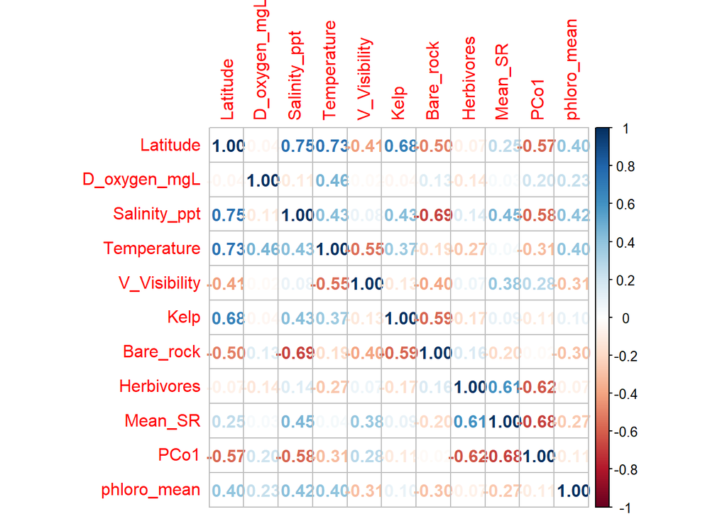

```r
Herb_all_num <- Herbivory_analysis %>%
  dplyr::select(-Site, -Bait2,-Consumed_proportion, -Day_length)
Herb_all_stand <- decostand(Herb_all_num, method="range")
#Test autocorrelation
corrplot(cor(Herb_all_stand), method = "number")
```

```r
Herb_all_stand$Site <- Herbivory_analysis$Site
Herb_all_stand$Consumption<- Herbivory_analysis$Consumption
Herb_all_stand$Consumed_proportion<- Herbivory_analysis$Consumed_proportion
```

### **6a)** Model selection

1. Temperature

```r
my_glmTL<- glm(Consumed_proportion ~  Temperature, data=Herb_all_stand, family = binomial)
summary(my_glmTL)
```

```
##
## Call:
## glm(formula = Consumed_proportion ~ Temperature, family = binomial,
##     data = Herb_all_stand)
##
## Coefficients:
##             Estimate Std. Error z value Pr(>|z|)
## (Intercept)  -0.7420     0.2145  -3.459 0.000542 ***
## Temperature  -0.7899     0.3171  -2.491 0.012738 *
## ---
## Signif. codes:  0 '***' 0.001 '**' 0.01 '*' 0.05 '.' 0.1 ' ' 1
##
## (Dispersion parameter for binomial family taken to be 1)
##
##     Null deviance: 491.97  on 589  degrees of freedom
## Residual deviance: 485.87  on 588  degrees of freedom
## AIC: 641.16
##
## Number of Fisher Scoring iterations: 4
```

```r
AICc(my_glmTL)
```

```
## [1] 641.184
```

```r
check_overdispersion(my_glmTL)
```

```
## # Overdispersion test
##
##  dispersion ratio =   0.784
##           p-value = < 0.001
```

```
## Underdispersion detected.
```

2. Salinity

```r
my_glmSL<- glm(Consumed_proportion ~  Salinity_ppt, data=Herb_all_stand, family = binomial)
summary(my_glmSL)
```

```
##
## Call:
## glm(formula = Consumed_proportion ~ Salinity_ppt, family = binomial,
##     data = Herb_all_stand)
##
## Coefficients:
##              Estimate Std. Error z value Pr(>|z|)
## (Intercept)    0.8452     0.2733   3.093  0.00198 **
## Salinity_ppt  -3.3000     0.4135  -7.980 1.46e-15 ***
## ---
## Signif. codes:  0 '***' 0.001 '**' 0.01 '*' 0.05 '.' 0.1 ' ' 1
##
## (Dispersion parameter for binomial family taken to be 1)
##
##     Null deviance: 491.97  on 589  degrees of freedom
## Residual deviance: 418.33  on 588  degrees of freedom
## AIC: 575.41
##
## Number of Fisher Scoring iterations: 4
```

```r
AICc(my_glmSL)
```

```
## [1] 575.4276
```

3. Dissolved oxygen

```r
my_glmOxL<- glm(Consumed_proportion ~  D_oxygen_mgL, data=Herb_all_stand, family = binomial)
summary(my_glmOxL)
```

```
##
## Call:
## glm(formula = Consumed_proportion ~ D_oxygen_mgL, family = binomial,
##     data = Herb_all_stand)
##
## Coefficients:
##              Estimate Std. Error z value Pr(>|z|)
## (Intercept)   -1.9163     0.1931  -9.922  < 2e-16 ***
## D_oxygen_mgL   1.4687     0.3319   4.425 9.63e-06 ***
## ---
## Signif. codes:  0 '***' 0.001 '**' 0.01 '*' 0.05 '.' 0.1 ' ' 1
##
## (Dispersion parameter for binomial family taken to be 1)
##
##     Null deviance: 491.97  on 589  degrees of freedom
## Residual deviance: 472.31  on 588  degrees of freedom
## AIC: 624.7
##
## Number of Fisher Scoring iterations: 4
```

```r
AICc(my_glmOxL)
```

```
## [1] 624.7162
```

4. Visibility

```r
my_glm<- glm(Consumed_proportion ~  V_Visibility, data=Herb_all_stand, family = binomial)
summary(my_glm)
```

```
##
## Call:
## glm(formula = Consumed_proportion ~ V_Visibility, family = binomial,
##     data = Herb_all_stand)
##
## Coefficients:
##              Estimate Std. Error z value Pr(>|z|)
## (Intercept)  -1.19110    0.18540  -6.424 1.32e-10 ***
## V_Visibility -0.09443    0.37397  -0.253    0.801
## ---
## Signif. codes:  0 '***' 0.001 '**' 0.01 '*' 0.05 '.' 0.1 ' ' 1
##
## (Dispersion parameter for binomial family taken to be 1)
##
##     Null deviance: 491.97  on 589  degrees of freedom
## Residual deviance: 491.91  on 588  degrees of freedom
## AIC: 648.94
##
## Number of Fisher Scoring iterations: 4
```

```r
AICc(my_glm)
```

```
## [1] 648.9651
```

5. Community composition

```r
my_glm<- glm(Consumed_proportion ~  PCo1, data=Herb_all_stand, family = binomial)
summary(my_glm)
```

```
##
## Call:
## glm(formula = Consumed_proportion ~ PCo1, family = binomial,
##     data = Herb_all_stand)
##
## Coefficients:
##             Estimate Std. Error z value Pr(>|z|)
## (Intercept)  -1.6529     0.1519 -10.885  < 2e-16 ***
## PCo1          1.0650     0.2652   4.016 5.91e-05 ***
## ---
## Signif. codes:  0 '***' 0.001 '**' 0.01 '*' 0.05 '.' 0.1 ' ' 1
##
## (Dispersion parameter for binomial family taken to be 1)
##
##     Null deviance: 491.97  on 589  degrees of freedom
## Residual deviance: 476.04  on 588  degrees of freedom
## AIC: 633.32
##
## Number of Fisher Scoring iterations: 4
```

```r
AICc(my_glm)
```

```
## [1] 633.3399
```

6. Kelp cover

```r
my_glm<- glm(Consumed_proportion ~  Kelp, data=Herb_all_stand, family = binomial)
summary(my_glm)
```

```
##
## Call:
## glm(formula = Consumed_proportion ~ Kelp, family = binomial,
##     data = Herb_all_stand)
##
## Coefficients:
##             Estimate Std. Error z value Pr(>|z|)
## (Intercept)  -0.9501     0.1366  -6.957 3.49e-12 ***
## Kelp         -1.1110     0.4085  -2.720  0.00653 **
## ---
## Signif. codes:  0 '***' 0.001 '**' 0.01 '*' 0.05 '.' 0.1 ' ' 1
##
## (Dispersion parameter for binomial family taken to be 1)
##
##     Null deviance: 491.97  on 589  degrees of freedom
## Residual deviance: 483.70  on 588  degrees of freedom
## AIC: 638.16
##
## Number of Fisher Scoring iterations: 4
```

```r
AICc(my_glm)
```

```
## [1] 638.1771
```

7. Bare rock cover

```r
my_glmBRL<- glm(Consumed_proportion ~  Bare_rock, data=Herb_all_stand, family = binomial)
summary(my_glmBRL)
```

```
##
## Call:
## glm(formula = Consumed_proportion ~ Bare_rock, family = binomial,
##     data = Herb_all_stand)
##
## Coefficients:
##             Estimate Std. Error z value Pr(>|z|)
## (Intercept)  -2.0942     0.1778 -11.780  < 2e-16 ***
## Bare_rock     1.9712     0.2940   6.704 2.03e-11 ***
## ---
## Signif. codes:  0 '***' 0.001 '**' 0.01 '*' 0.05 '.' 0.1 ' ' 1
##
## (Dispersion parameter for binomial family taken to be 1)
##
##     Null deviance: 491.97  on 589  degrees of freedom
## Residual deviance: 445.04  on 588  degrees of freedom
## AIC: 603.94
##
## Number of Fisher Scoring iterations: 4
```

```r
AICc(my_glmBRL)
```

```
## [1] 603.9645
```

8. Species richness

```r
my_glm<- glm(Consumed_proportion ~  Mean_SR, data=Herb_all_stand, family = binomial)
summary(my_glm)
```

```
##
## Call:
## glm(formula = Consumed_proportion ~ Mean_SR, family = binomial,
##     data = Herb_all_stand)
##
## Coefficients:
##             Estimate Std. Error z value Pr(>|z|)
## (Intercept)  -1.3117     0.1946  -6.740 1.58e-11 ***
## Mean_SR       0.1688     0.3484   0.485    0.628
## ---
## Signif. codes:  0 '***' 0.001 '**' 0.01 '*' 0.05 '.' 0.1 ' ' 1
##
## (Dispersion parameter for binomial family taken to be 1)
##
##     Null deviance: 491.97  on 589  degrees of freedom
## Residual deviance: 491.74  on 588  degrees of freedom
## AIC: 647.32
##
## Number of Fisher Scoring iterations: 4
```

```r
AICc(my_glm)
```

```
## [1] 647.339
```

9. Abundance of herbivores

```r
my_glm<- glm(Consumed_proportion ~  Herbivores, data=Herb_all_stand, family = binomial)
summary(my_glm)
```

```
##
## Call:
## glm(formula = Consumed_proportion ~ Herbivores, family = binomial,
##     data = Herb_all_stand)
##
## Coefficients:
##             Estimate Std. Error z value Pr(>|z|)
## (Intercept)  -1.2632     0.1225 -10.308   <2e-16 ***
## Herbivores    0.1492     0.3326   0.449    0.654
## ---
## Signif. codes:  0 '***' 0.001 '**' 0.01 '*' 0.05 '.' 0.1 ' ' 1
##
## (Dispersion parameter for binomial family taken to be 1)
##
##     Null deviance: 491.97  on 589  degrees of freedom
## Residual deviance: 491.77  on 588  degrees of freedom
## AIC: 647.94
##
## Number of Fisher Scoring iterations: 4
```

```r
AICc(my_glm)
```

```
## [1] 647.9606
```

10. Phlorotannins

```r
my_glmPH<- glm(Consumed_proportion ~  phloro_mean, data=Herb_all_stand, family = binomial)
summary(my_glmPH)
```

```
##
## Call:
## glm(formula = Consumed_proportion ~ phloro_mean, family = binomial,
##     data = Herb_all_stand)
##
## Coefficients:
##             Estimate Std. Error z value Pr(>|z|)
## (Intercept)  -0.2487     0.1392  -1.787   0.0739 .
## phloro_mean  -4.5287     0.6353  -7.128 1.02e-12 ***
## ---
## Signif. codes:  0 '***' 0.001 '**' 0.01 '*' 0.05 '.' 0.1 ' ' 1
##
## (Dispersion parameter for binomial family taken to be 1)
##
##     Null deviance: 491.97  on 589  degrees of freedom
## Residual deviance: 398.55  on 588  degrees of freedom
## AIC: 544.61
##
## Number of Fisher Scoring iterations: 6
```

```r
AICc(my_glmPH)
```

```
## [1] 544.6339
```

## **Part 7**: Visualisation of best fitted predictors

### **7a):** Crab consumption

Make predictions according to individual models with lowest AICc

1. Crabs 2 h

```r
newdfrC2hT = expand.grid(Temperature = rep(seq(from = min(Crabs2_stand$Temperature), to = max(Crabs2_stand$Temperature), length.out = 100), 5))

#add preditions
dat1 <- predict(my_glmT, newdata = newdfrC2hT, type = "link", se.fit = TRUE)
critval <- 1.96 ## approx 95% CI
upr <- dat1$fit + (critval * dat1$se.fit)
lwr <- dat1$fit - (critval * dat1$se.fit)
fit <- dat1$fit
fit2 <- my_glmT$family$linkinv(fit)
upr2 <- my_glmT$family$linkinv(upr)
lwr2 <- my_glmT$family$linkinv(lwr)

newdfrC2hT$lwr <- lwr2
newdfrC2hT$upr <- upr2
newdfrC2hT$fit <- fit2
#For Salinity

newdfrC2S = expand.grid(D_oxygen_mgL = rep(seq(from = min(Crabs2_stand$D_oxygen_mgL), to = max(Crabs2_stand$D_oxygen_mgL), length.out = 100), 5))

dat2 <- predict(my_glmOx, newdata = newdfrC2S, type = "link", se.fit = TRUE)
upr1 <- dat2$fit + (critval * dat2$se.fit)
lwr1 <- dat2$fit - (critval * dat2$se.fit)
fit1 <- dat2$fit
fit3 <- my_glmOx$family$linkinv(fit1)
upr3 <- my_glmOx$family$linkinv(upr1)
lwr3 <- my_glmOx$family$linkinv(lwr1)

newdfrC2S$lwr <- lwr3
newdfrC2S$upr <- upr3
newdfrC2S$fit <- fit3


#For Bare rock cover

newdfrC2BR = expand.grid(Bare_rock = rep(seq(from = min(Crabs2_stand$Bare_rock), to = max(Crabs2_stand$Bare_rock), length.out = 100), 5))

dat2 <- predict(my_glmBR, newdata = newdfrC2BR , type = "link", se.fit = TRUE)
upr1 <- dat2$fit + (critval * dat2$se.fit)
lwr1 <- dat2$fit - (critval * dat2$se.fit)
fit1 <- dat2$fit
fit3 <- my_glmBR$family$linkinv(fit1)
upr3 <- my_glmBR$family$linkinv(upr1)
lwr3 <- my_glmBR$family$linkinv(lwr1)

newdfrC2BR$lwr <- lwr3
newdfrC2BR$upr <- upr3
newdfrC2BR$fit <- fit3

#For Salinity

newdfrC2Sal = expand.grid(Salinity_ppt = rep(seq(from = min(Crabs2_stand$Salinity_ppt), to = max(Crabs2_stand$Salinity_ppt), length.out = 100), 5))

dat2 <- predict(my_glmSC2, newdata = newdfrC2Sal , type = "link", se.fit = TRUE)
upr1 <- dat2$fit + (critval * dat2$se.fit)
lwr1 <- dat2$fit - (critval * dat2$se.fit)
fit1 <- dat2$fit
fit3 <- my_glmSC2$family$linkinv(fit1)
upr3 <- my_glmSC2$family$linkinv(upr1)
lwr3 <- my_glmSC2$family$linkinv(lwr1)

newdfrC2Sal$lwr <- lwr3
newdfrC2Sal$upr <- upr3
newdfrC2Sal$fit <- fit3
```

2. Crabs 24 h

```r
newdfrC24T = expand.grid(Temperature = rep(seq(from = min(Crabs24_stand$Temperature), to = max(Crabs24_stand$Temperature), length.out = 100), 5))

#add preditions
dat1 <- predict(my_glmT24, newdata = newdfrC24T, type = "link", se.fit = TRUE)
critval <- 1.96 ## approx 95% CI
upr <- dat1$fit + (critval * dat1$se.fit)
lwr <- dat1$fit - (critval * dat1$se.fit)
fit <- dat1$fit
fit2 <- my_glmT24$family$linkinv(fit)
upr2 <- my_glmT24$family$linkinv(upr)
lwr2 <- my_glmT24$family$linkinv(lwr)

newdfrC24T$lwr <- lwr2
newdfrC24T$upr <- upr2
newdfrC24T$fit <- fit2
#For Salinity

newdfrC24S = expand.grid(Salinity_ppt = rep(seq(from = min(Crabs24_stand$Salinity_ppt), to = max(Crabs24_stand$Salinity_ppt), length.out = 100), 5))

dat2 <- predict(my_glmS24, newdata = newdfrC24S, type = "link", se.fit = TRUE)
upr1 <- dat2$fit + (critval * dat2$se.fit)
lwr1 <- dat2$fit - (critval * dat2$se.fit)
fit1 <- dat2$fit
fit3 <- my_glmS24$family$linkinv(fit1)
upr3 <- my_glmS24$family$linkinv(upr1)
lwr3 <- my_glmS24$family$linkinv(lwr1)

newdfrC24S$lwr <- lwr3
newdfrC24S$upr <- upr3
newdfrC24S$fit <- fit3


#For Bare rock cover

newdfrC24BR = expand.grid(Bare_rock = rep(seq(from = min(Crabs24_stand$Bare_rock), to = max(Crabs24_stand$Bare_rock), length.out = 100), 5))

dat2 <- predict(my_glmBR24, newdata = newdfrC24BR , type = "link", se.fit = TRUE)
upr1 <- dat2$fit + (critval * dat2$se.fit)
lwr1 <- dat2$fit - (critval * dat2$se.fit)
fit1 <- dat2$fit
fit3 <- my_glmBR24$family$linkinv(fit1)
upr3 <- my_glmBR24$family$linkinv(upr1)
lwr3 <- my_glmBR24$family$linkinv(lwr1)

newdfrC24BR$lwr <- lwr3
newdfrC24BR$upr <- upr3
newdfrC24BR$fit <- fit3

#For Fish length

newdfrC24FL = expand.grid(Fish_size = rep(seq(from = min(Crabs24_stand$Fish_size), to = max(Crabs24_stand$Fish_size), length.out = 100), 5))

dat2 <- predict(my_glm24_FL, newdata = newdfrC24FL , type = "link", se.fit = TRUE)
upr1 <- dat2$fit + (critval * dat2$se.fit)
lwr1 <- dat2$fit - (critval * dat2$se.fit)
fit1 <- dat2$fit
fit3 <- my_glm24_FL$family$linkinv(fit1)
upr3 <- my_glm24_FL$family$linkinv(upr1)
lwr3 <- my_glm24_FL$family$linkinv(lwr1)

newdfrC24FL$lwr <- lwr3
newdfrC24FL$upr <- upr3
newdfrC24FL$fit <- fit3
```

**1)** Temperature vs Crabs

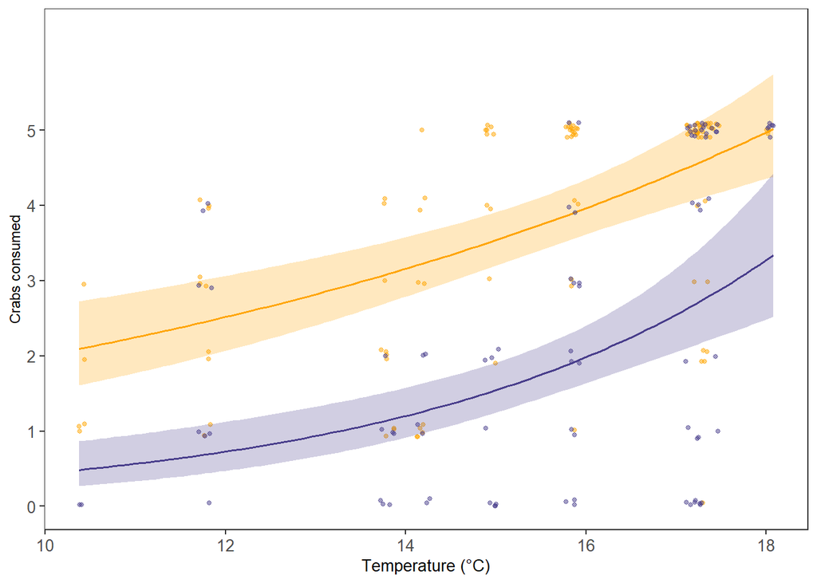

```r
ggplot() +
  geom_ribbon(data = newdfrC24T, aes(x = Temperature, y = fit, ymin = lwr, ymax = upr), fill = "orange1", alpha = .25) +
  geom_line(data = newdfrC24T, aes(x = Temperature, y =fit), color =  "orange1", linewidth = 0.6) +
  geom_jitter(data = Crabs24_stand, aes(x= Temperature, y=Consumed_individuals), color = "orange1", width=0.01, height = 0.1, size = 1, alpha = 0.5)+
  geom_ribbon(data = newdfrC2hT, aes(x = Temperature, y = fit, ymin = lwr, ymax = upr), fill = "darkslateblue", alpha = .25) +
  geom_line(data = newdfrC2hT, aes(x = Temperature, y =fit), color =  "darkslateblue", linewidth = 0.6) +
  geom_jitter(data = Crabs2_stand, aes(x= Temperature, y=Consumed_individuals), color = "darkslateblue", width=0.01, height = 0.1, size = 1, alpha = 0.5)+
  labs(x = "Temperature (°C)", y = "Crabs consumed")  + Theme1 +
  scale_x_continuous(breaks = c(-0.04868, 0.21096, 0.4706, 0.73023, 0.98987), labels = c("10", "12", "14", "16", "18"), limits = c(0,1)) +
  scale_y_continuous(limits = c(0,6.3), breaks = seq(0, 5, 1))
```

```r
ggsave("TempC.jpeg", units="mm", width=110, height=80, dpi=300)
```

**2)** Salinity vs Crabs

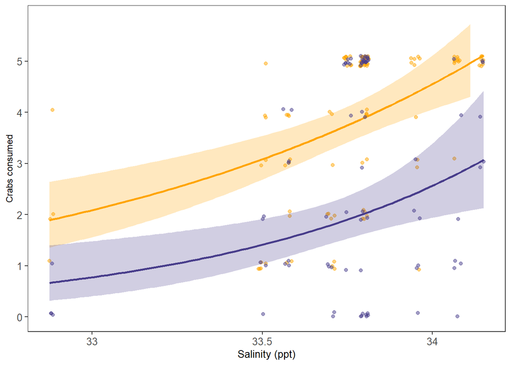

```r
ggplot() +
  geom_ribbon(data = newdfrC24S, aes(x = Salinity_ppt, y = fit, ymin = lwr, ymax = upr), fill = "orange1", alpha = .25) +
  geom_line(data = newdfrC24S, aes(x = Salinity_ppt, y =fit), color =  "orange1", size = 1) +
  geom_jitter(data = Crabs24_stand, aes(x= Salinity_ppt, y=Consumed_individuals), color = "orange1", width=0.01, height = 0.1, size = 1.5, alpha = 0.5)+
  geom_ribbon(data = newdfrC2Sal, aes(x = Salinity_ppt, y = fit, ymin = lwr, ymax = upr), fill = "darkslateblue", alpha = .25) +
  geom_line(data = newdfrC2Sal, aes(x = Salinity_ppt, y =fit), color =  "darkslateblue", size = 1) +
  geom_jitter(data = Crabs2_stand, aes(x= Salinity_ppt, y=Consumed_individuals), color = "darkslateblue", width=0.01, height = 0.1, size = 1.5, alpha = 0.5)+
  labs(x = "Salinity (ppt)", y = "Crabs consumed")  + Theme1 +
  scale_x_continuous(breaks = c(0.09803922, 0.49019608, 0.88235299, 1.2745098), labels = c("33", "33.5", "34", "33.5"), limits = c(0,1)) +
  scale_y_continuous(limits = c(0,5.8), breaks = seq(0, 5, 1)) +
  theme(legend.position = c(0.1, 0.85))
```

```r
ggsave("SalC.jpeg", units="mm", width=110, height=90, dpi=300)
```

**3)** Oxygen vs Crabs

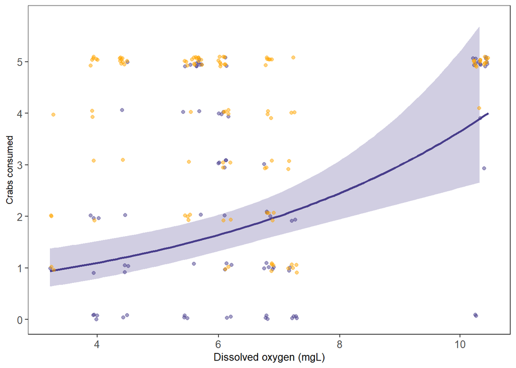

```r
ggplot() +
  geom_ribbon(data = newdfrC2S, aes(x = D_oxygen_mgL, y = fit, ymin = lwr, ymax = upr), fill = "darkslateblue", alpha = .25) +
  geom_line(data = newdfrC2S, aes(x = D_oxygen_mgL, y =fit), color =  "darkslateblue", size = 1) +
  geom_jitter(data = Crabs2_stand, aes(x= D_oxygen_mgL, y=Consumed_individuals), color = "darkslateblue", width=0.01, height = 0.1, size = 1.5, alpha = 0.5)+
  geom_jitter(data = Crabs24_stand, aes(x= D_oxygen_mgL, y=Consumed_individuals), color = "orange1", width=0.01, height = 0.1, size = 1.5, alpha = 0.5)+
  labs(x = "Dissolved oxygen (mgL)", y = "Crabs consumed")  + Theme1 +
  scale_x_continuous(breaks = c(0.1082296, 0.384854, 0.66147994, 0.935517247), labels = c("4", "6", "8", "10"), limits = c(0,1)) +
  scale_y_continuous(limits = c(0,5.8), breaks = seq(0, 5, 1)) +
  theme(legend.position = c(0.1, 0.85))
```

```r
ggsave("OxC.jpeg", units="mm", width=110, height=80, dpi=300)
```

**4)** Bare rock Crabs 24 h

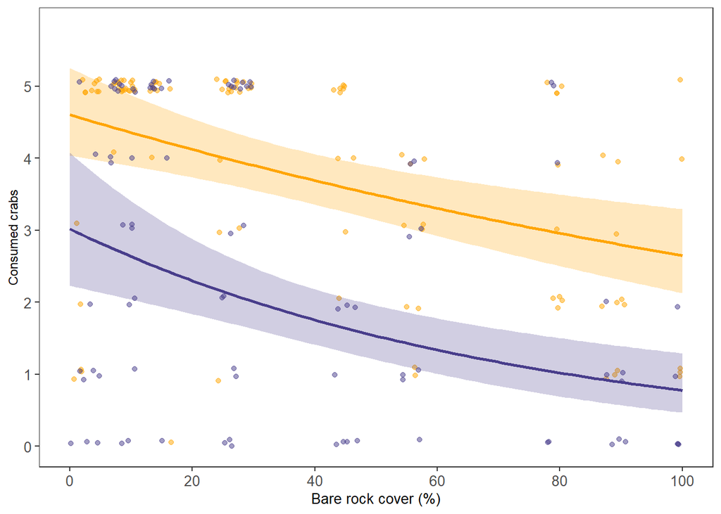

```r
ggplot() +
  geom_ribbon(data = newdfrC24BR, aes(x = Bare_rock, y = fit, ymin = lwr, ymax = upr), fill = "orange1", alpha = .25) +
  geom_line(data = newdfrC24BR, aes(x = Bare_rock, y =fit), color =  "orange1", size = 1) +
  geom_jitter(data = Crabs24_stand, aes(x= Bare_rock, y=Consumed_individuals), color = "orange1", width=0.02, height = 0.1, size = 1.5, alpha = 0.5)+
  geom_ribbon(data = newdfrC2BR, aes(x = Bare_rock, y = fit, ymin = lwr, ymax = upr), fill = "darkslateblue", alpha = .25) +
  geom_line(data = newdfrC2BR, aes(x = Bare_rock, y =fit), color =  "darkslateblue", size = 1) +
  geom_jitter(data = Crabs2_stand, aes(x= Bare_rock, y=Consumed_individuals), color = "darkslateblue", width=0.02, height = 0.1, size = 1.5, alpha = 0.5)+
  labs(x = "Bare rock cover (%)", y = "Consumed crabs")  + Theme1 +
  scale_x_continuous(breaks = c(0, 0.2, 0.4, 0.6, 0.8, 1), labels = c("0", "20", "40", "60", "80", "100"), limits = c(0,1)) +
  scale_y_continuous(limits = c(0,5.8), breaks = seq(0, 5, 1)) +
  theme(legend.position = c(0.1, 0.85))
```

```r
ggsave("BareC.jpeg", units="mm", width=110, height=80, dpi=300)
```

**4)** Fish length - Crabs 24 h

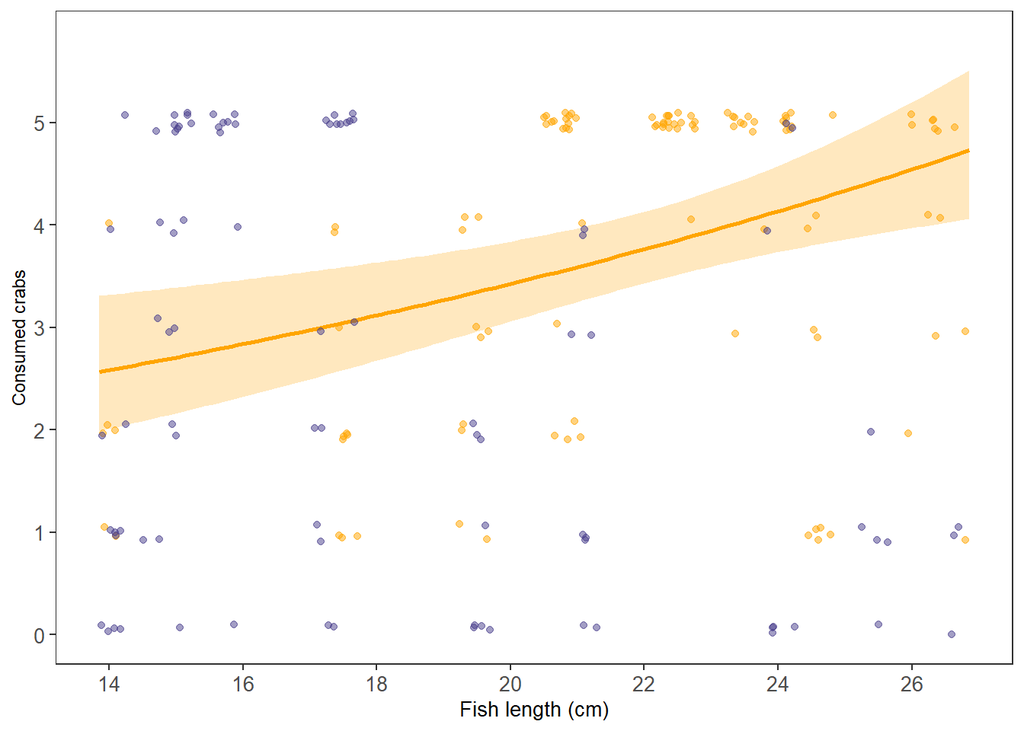

```r
ggplot() +
  geom_ribbon(data = newdfrC24FL, aes(x = Fish_size, y = fit, ymin = lwr, ymax = upr), fill = "orange1", alpha = .25) +
  geom_line(data = newdfrC24FL, aes(x = Fish_size, y =fit), color =  "orange1", size = 1) +
  geom_jitter(data = Crabs24_stand, aes(x= Fish_size, y=Consumed_individuals), color = "orange1", width=0.02, height = 0.1, size = 1.5, alpha = 0.5)+
  geom_jitter(data = Crabs2_stand, aes(x= Bare_rock, y=Consumed_individuals), color = "darkslateblue", width=0.02, height = 0.1, size = 1.5, alpha = 0.5)+
  labs(x = "Fish length (cm)", y = "Consumed crabs")  + Theme1 +
  scale_x_continuous(breaks = c(0.011979959
,0.165667696
, 0.319355434
, 0.473043171
, 0.626730908
, 0.780418645
,0.934106383), labels = c("14","16", "18", "20", "22", "24", "26"), limits = c(0,1)) +
  scale_y_continuous(limits = c(0,5.8), breaks = seq(0, 5, 1)) +
  theme(legend.position = c(0.1, 0.85))
```

```r
ggsave("Fish_length.jpeg", units="mm", width=110, height=80, dpi=300)
```

### **7b):** Squidpop consumption

1. Squidpops 2 h

```r
S2Ox = expand.grid(D_oxygen_mgL = rep(seq(from = min(Squidpops2_stand$D_oxygen_mgL), to = max(Squidpops2_stand$D_oxygen_mgL), length.out = 100), 5))

#add preditions
dat1 <- predict(my_glmOxS, newdata = S2Ox, type = "link", se.fit = TRUE)
critval <- 1.96 ## approx 95% CI
upr <- dat1$fit + (critval * dat1$se.fit)
lwr <- dat1$fit - (critval * dat1$se.fit)
fit <- dat1$fit
fit2 <- my_glmOxS$family$linkinv(fit)
upr2 <- my_glmOxS$family$linkinv(upr)
lwr2 <- my_glmOxS$family$linkinv(lwr)

S2Ox$lwr <- lwr2
S2Ox$upr <- upr2
S2Ox$fit <- fit2
#For Pco

S2PCo1 = expand.grid(PCo1 = rep(seq(from = min(Squidpops2_stand$PCo1), to = max(Squidpops2_stand$PCo1), length.out = 100), 5))

#add preditions
dat1 <- predict(my_glmPC, newdata = S2PCo1, type = "link", se.fit = TRUE)
critval <- 1.96 ## approx 95% CI
upr <- dat1$fit + (critval * dat1$se.fit)
lwr <- dat1$fit - (critval * dat1$se.fit)
fit <- dat1$fit
fit2 <- my_glmPC$family$linkinv(fit)
upr2 <- my_glmPC$family$linkinv(upr)
lwr2 <- my_glmPC$family$linkinv(lwr)

S2PCo1$lwr <- lwr2
S2PCo1$upr <- upr2
S2PCo1$fit <- fit2


#For Fish length


S2FL = expand.grid(Fish_size = rep(seq(from = min(Squidpops2_stand$Fish_size), to = max(Squidpops2_stand$Fish_size), length.out = 100), 5))

#add preditions
dat1 <- predict(my_glmL, newdata = S2FL, type = "link", se.fit = TRUE)
critval <- 1.96 ## approx 95% CI
upr <- dat1$fit + (critval * dat1$se.fit)
lwr <- dat1$fit - (critval * dat1$se.fit)
fit <- dat1$fit
fit2 <- my_glmL$family$linkinv(fit)
upr2 <- my_glmL$family$linkinv(upr)
lwr2 <- my_glmL$family$linkinv(lwr)

S2FL$lwr <- lwr2
S2FL$upr <- upr2
S2FL$fit <- fit2
```

2. Squidpops 24 h

```r
S24T = expand.grid(Temperature = rep(seq(from = min(Squidpops24_stand$Temperature), to = max(Squidpops24_stand$Temperature), length.out = 100), 5))

#add preditions
dat1 <- predict(my_glmTS24, newdata = S24T, type = "link", se.fit = TRUE)
critval <- 1.96 ## approx 95% CI
upr <- dat1$fit + (critval * dat1$se.fit)
lwr <- dat1$fit - (critval * dat1$se.fit)
fit <- dat1$fit
fit2 <- my_glmTS24$family$linkinv(fit)
upr2 <- my_glmTS24$family$linkinv(upr)
lwr2 <- my_glmTS24$family$linkinv(lwr)

S24T$lwr <- lwr2
S24T$upr <- upr2
S24T$fit <- fit2
#For Salinity

S24Sal = expand.grid(Salinity_ppt = rep(seq(from = min(Squidpops24_stand$Salinity_ppt), to = max(Squidpops24_stand$Salinity_ppt), length.out = 100), 5))

#add preditions
dat1 <- predict(my_glmSS24, newdata = S24Sal, type = "link", se.fit = TRUE)
critval <- 1.96 ## approx 95% CI
upr <- dat1$fit + (critval * dat1$se.fit)
lwr <- dat1$fit - (critval * dat1$se.fit)
fit <- dat1$fit
fit2 <- my_glmSS24$family$linkinv(fit)
upr2 <- my_glmSS24$family$linkinv(upr)
lwr2 <- my_glmSS24$family$linkinv(lwr)

S24Sal$lwr <- lwr2
S24Sal$upr <- upr2
S24Sal$fit <- fit2
```

**1)** Temperature vs squidpops

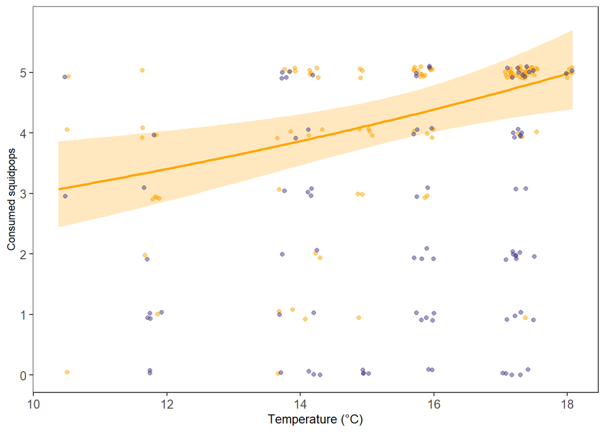

```r
ggplot() +
  geom_ribbon(data = S24T, aes(x = Temperature, y = fit, ymin = lwr, ymax = upr), fill = "orange1", alpha = .25) +
  geom_line(data = S24T, aes(x = Temperature, y =fit), color =  "orange1", size = 1) +
  geom_jitter(data = Squidpops24_stand, aes(x= Temperature, y=Consumed_individuals), color = "orange1", width=0.02, height = 0.1, size = 1.5, alpha = 0.5)+
   geom_jitter(data = Squidpops2_stand, aes(x= Temperature, y=Consumed_individuals), color = "darkslateblue", width=0.02, height = 0.1, size = 1.5, alpha = 0.5)+
  labs(x = "Temperature (°C)", y = "Consumed squidpops")  + Theme1 +
  scale_x_continuous(breaks = c(-0.04868, 0.21096, 0.4706, 0.73023, 0.98987), labels = c("10", "12", "14", "16", "18"), limits = c(0,1)) +
  scale_y_continuous(limits = c(0,5.8), breaks = seq(0, 5, 1)) +
  theme(legend.position = c(0.1, 0.85))
```

```r
ggsave("TemperatureS.jpeg", units="mm", width=110, height=80, dpi=300)
```

**2)** Salinity vs squidpops

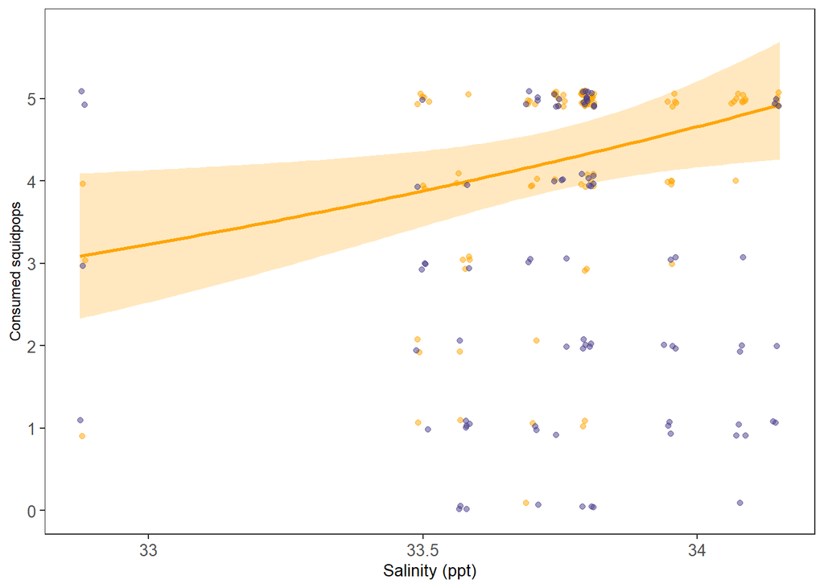

```r
ggplot() +
  geom_ribbon(data = S24Sal, aes(x = Salinity_ppt, y = fit, ymin = lwr, ymax = upr), fill = "orange1", alpha = .25) +
  geom_line(data = S24Sal, aes(x = Salinity_ppt, y =fit), color =  "orange1", size = 1) +
  geom_jitter(data = Squidpops24_stand, aes(x= Salinity_ppt, y=Consumed_individuals), color = "orange1", width=0.01, height = 0.1, size = 1.5, alpha = 0.5)+
   geom_jitter(data = Squidpops2_stand, aes(x= Salinity_ppt, y=Consumed_individuals), color = "darkslateblue", width=0.01, height = 0.1, size = 1.5, alpha = 0.5)+
  labs(x = "Salinity (ppt)", y = "Consumed squidpops")  + Theme1 +
  scale_x_continuous(breaks = c(0.09803922, 0.49019608, 0.88235299, 1.2745098), labels = c("33", "33.5", "34", "33.5"), limits = c(0,1)) +
  scale_y_continuous(limits = c(0,5.8), breaks = seq(0, 5, 1)) +
  theme(legend.position = c(0.1, 0.85))
```

```r
ggsave("SalS.jpeg", units="mm", width=110, height=80, dpi=300)
```

**3)** Oxygen vs squidpops

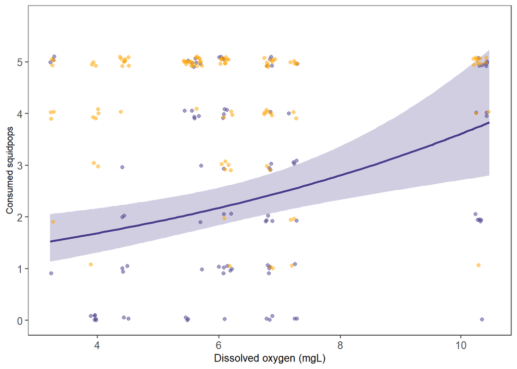

```r
ggplot() +
  geom_ribbon(data = S2Ox, aes(x = D_oxygen_mgL, y = fit, ymin = lwr, ymax = upr), fill = "darkslateblue", alpha = .25) +
  geom_line(data = S2Ox, aes(x = D_oxygen_mgL, y =fit), color =  "darkslateblue", size = 1) +
  geom_jitter(data = Squidpops2_stand, aes(x= D_oxygen_mgL, y=Consumed_individuals), color = "darkslateblue", width=0.01, height = 0.1, size = 1.5, alpha = 0.5)+
  geom_jitter(data = Squidpops24_stand, aes(x= D_oxygen_mgL, y=Consumed_individuals), color = "orange1", width=0.01, height = 0.1, size = 1.5, alpha = 0.5)+
  labs(x = "Dissolved oxygen (mgL)", y = "Consumed squidpops")  + Theme1 +
  scale_x_continuous(breaks = c(0.1082296, 0.384854, 0.66147994, 0.935517247), labels = c("4", "6", "8", "10"), limits = c(0,1)) +
  scale_y_continuous(limits = c(0,5.8), breaks = seq(0, 5, 1)) +
  theme(legend.position = c(0.1, 0.85))
```

```r
ggsave("OxS.jpeg", units="mm", width=110, height=80, dpi=300)
```

[figure not shown]

```r
ggplot() +
  geom_jitter(data = Squidpops2_stand, aes(x= Fish_size, y=Consumed_individuals), color = "darkslateblue", width=0.015, height = 0.1, size = 1.5, alpha = 0.5)+
    geom_jitter(data = Squidpops24_stand, aes(x= Fish_size, y=Consumed_individuals), color = "orange1", width=0.015, height = 0.1, size = 1.5, alpha = 0.5)+
  labs(x = "Bare rock cover (%)", y = "Consumed squidpops")  + Theme1 +
  scale_x_continuous(breaks = c(0, 0.2, 0.4, 0.6, 0.8, 1), labels = c("0", "20", "40", "60", "80", "100"), limits = c(0,1)) +
  scale_y_continuous(limits = c(0,5.8), breaks = seq(0, 5, 1)) +
  theme(legend.position = c(0.1, 0.85))
```

```r
ggsave("BRS.jpeg", units="mm", width=110, height=80, dpi=300)
```

5. Fish length vs squidpops

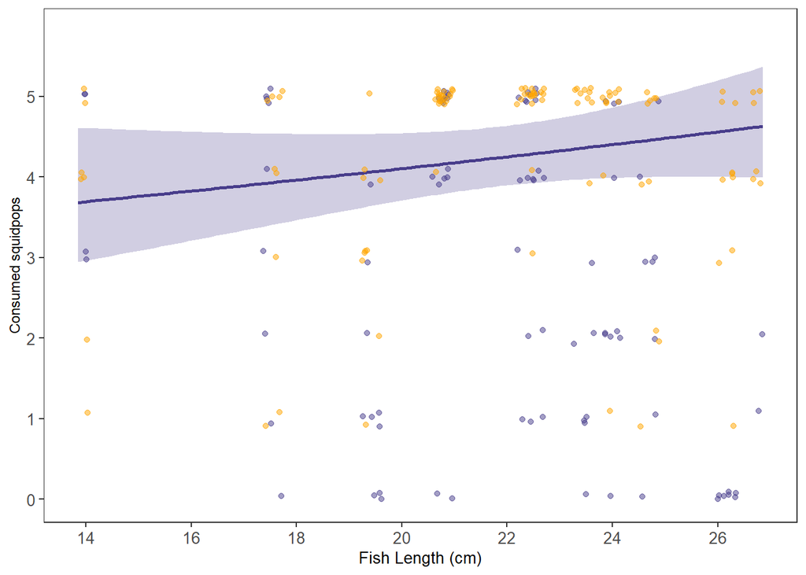

```r
ggplot() +
  geom_ribbon(data = S2FL, aes(x = Fish_size, y = fit, ymin = lwr, ymax = upr), fill = "darkslateblue", alpha = .25) +
  geom_line(data = S2FL, aes(x = Fish_size, y =fit), color =  "darkslateblue", size = 1) +
  geom_jitter(data = Squidpops2_stand, aes(x= Fish_size, y=Consumed_individuals), color = "darkslateblue", width=0.015, height = 0.1, size = 1.5, alpha = 0.5)+
    geom_jitter(data = Squidpops24_stand, aes(x= Fish_size, y=Consumed_individuals), color = "orange1", width=0.015, height = 0.1, size = 1.5, alpha = 0.5)+
  labs(x = "Fish Length (cm)", y = "Consumed squidpops")  + Theme1 +
  scale_x_continuous(breaks = c(0.011979959
,0.165667696
, 0.319355434
, 0.473043171
, 0.626730908
, 0.780418645
,0.934106383), labels = c("14","16", "18", "20", "22", "24", "26"), limits = c(0,1)) +
  scale_y_continuous(limits = c(0,5.8), breaks = seq(0, 5, 1)) +
  theme(legend.position = c(0.1, 0.85))
```

```r
ggsave("FLS2.jpeg", units="mm", width=110, height=80, dpi=300)
```

### **7c):** Seaweed consumption

```r
LPhlo = expand.grid(phloro_mean = rep(seq(from = min(Herb_all_stand$phloro_mean), to = max(Herb_all_stand$phloro_mean), length.out = 100), 5))

#add preditions
dat1 <- predict(my_glmPH, newdata = LPhlo, type = "link", se.fit = TRUE)
critval <- 1.96 ## approx 95% CI
upr <- dat1$fit + (critval * dat1$se.fit)
lwr <- dat1$fit - (critval * dat1$se.fit)
fit <- dat1$fit
fit2 <- my_glmPH$family$linkinv(fit)
upr2 <- my_glmPH$family$linkinv(upr)
lwr2 <- my_glmPH$family$linkinv(lwr)

LPhlo$lwr <- lwr2
LPhlo$upr <- upr2
LPhlo$fit <- fit2

#For Salinity
LSal = expand.grid(Salinity_ppt = rep(seq(from = min(Herb_all_stand$Salinity_ppt), to = max(Herb_all_stand$Salinity_ppt), length.out = 100), 5))

#add preditions
dat1 <- predict(my_glmSL, newdata = LSal, type = "link", se.fit = TRUE)
critval <- 1.96 ## approx 95% CI
upr <- dat1$fit + (critval * dat1$se.fit)
lwr <- dat1$fit - (critval * dat1$se.fit)
fit <- dat1$fit
fit2 <- my_glmSL$family$linkinv(fit)
upr2 <- my_glmSL$family$linkinv(upr)
lwr2 <- my_glmSL$family$linkinv(lwr)

LSal$lwr <- lwr2
LSal$upr <- upr2
LSal$fit <- fit2

#For Bare rock cover

LBR = expand.grid(Bare_rock = rep(seq(from = min(Herb_all_stand$Bare_rock), to = max(Herb_all_stand$Bare_rock), length.out = 100), 5))

#add preditions
dat1 <- predict(my_glmBRL, newdata = LBR, type = "link", se.fit = TRUE)
critval <- 1.96 ## approx 95% CI
upr <- dat1$fit + (critval * dat1$se.fit)
lwr <- dat1$fit - (critval * dat1$se.fit)
fit <- dat1$fit
fit2 <- my_glmBRL$family$linkinv(fit)
upr2 <- my_glmBRL$family$linkinv(upr)
lwr2 <- my_glmBRL$family$linkinv(lwr)

LBR$lwr <- lwr2
LBR$upr <- upr2
LBR$fit <- fit2

#For Temperature

LTEMP = expand.grid(Temperature = rep(seq(from = min(Herb_all_stand$Temperature), to = max(Herb_all_stand$Temperature), length.out = 100), 5))

#add preditions
dat1 <- predict(my_glmTL, newdata = LTEMP, type = "link", se.fit = TRUE)
critval <- 1.96 ## approx 95% CI
upr <- dat1$fit + (critval * dat1$se.fit)
lwr <- dat1$fit - (critval * dat1$se.fit)
fit <- dat1$fit
fit2 <- my_glmTL$family$linkinv(fit)
upr2 <- my_glmTL$family$linkinv(upr)
lwr2 <- my_glmTL$family$linkinv(lwr)

LTEMP$lwr <- lwr2
LTEMP$upr <- upr2
LTEMP$fit <- fit2

#For oxygen

LOx = expand.grid(D_oxygen_mgL = rep(seq(from = min(Herb_all_stand$D_oxygen_mgL), to = max(Herb_all_stand$D_oxygen_mgL), length.out = 100), 5))

#add preditions
dat1 <- predict(my_glmOxL, newdata = LOx, type = "link", se.fit = TRUE)
critval <- 1.96 ## approx 95% CI
upr <- dat1$fit + (critval * dat1$se.fit)
lwr <- dat1$fit - (critval * dat1$se.fit)
fit <- dat1$fit
fit2 <- my_glmOxL$family$linkinv(fit)
upr2 <- my_glmOxL$family$linkinv(upr)
lwr2 <- my_glmOxL$family$linkinv(lwr)

LOx$lwr <- lwr2
LOx$upr <- upr2
LOx$fit <- fit2
```

1. Phlorotannins vs herbivory

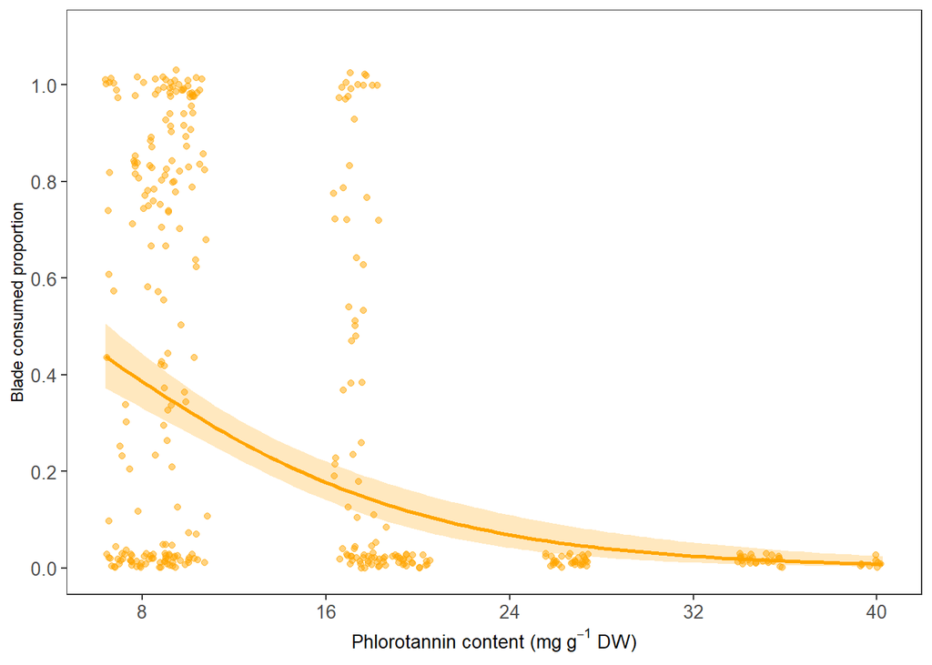

```r
ggplot() +
  geom_ribbon(data = LPhlo, aes(x = phloro_mean, y = fit, ymin = lwr, ymax = upr), fill = "orange1", alpha = .25) +
  geom_line(data = LPhlo, aes(x = phloro_mean, y =fit), color =  "orange1", size = 1) +
  geom_jitter(data = Herb_all_stand, aes(x= phloro_mean, y=Consumed_proportion), color = "orange1", width=0.03, height = 0.03, size = 1.5, alpha = 0.5)+
  labs(x = "Phlorotannin content (mg"~g^-1*" DW)", y = "Blade consumed proportion")  + Theme1 +
  scale_x_continuous(breaks = c(0.04788192, 0.2840443, 0.5202066, 0.756369, 0.9925314), labels = c("8", "16", "24", "32", "40"), limits = c(0,1)) +
  scale_y_continuous(limits = c(0,1.1), breaks = seq(0, 1, 0.2)) +
  theme(legend.position = c(0.1, 0.85))
```

```r
ggsave("PhloroL.jpeg", units="mm", width=110, height=80, dpi=300)
```

2. Salinity vs herbivory

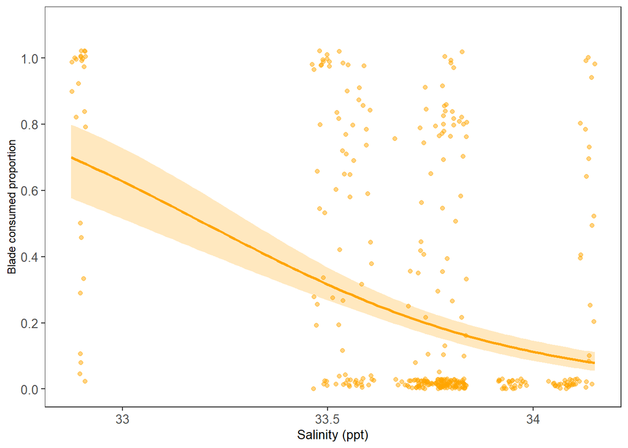

```r
ggplot() +
  geom_ribbon(data = LSal, aes(x = Salinity_ppt, y = fit, ymin = lwr, ymax = upr), fill = "orange1", alpha = .25) +
  geom_line(data = LSal, aes(x = Salinity_ppt, y =fit), color =  "orange1", size = 1) +
  geom_jitter(data = Herb_all_stand, aes(x= Salinity_ppt, y=Consumed_proportion), color = "orange1", width=0.03, height = 0.03, size = 1.5, alpha = 0.5)+
  labs(x = "Salinity (ppt)", y = "Blade consumed proportion")  + Theme1 +
  scale_x_continuous(breaks = c(0.09803922, 0.49019608, 0.88235299, 1.2745098), labels = c("33", "33.5", "34", "33.5"), limits = c(0,1)) +
  scale_y_continuous(limits = c(0,1.1), breaks = seq(0, 1, 0.2)) +
  theme(legend.position = c(0.1, 0.85))
```

```r
ggsave("SalL.jpeg", units="mm", width=110, height=80, dpi=300)
```

3. Bare rock vs herbivory

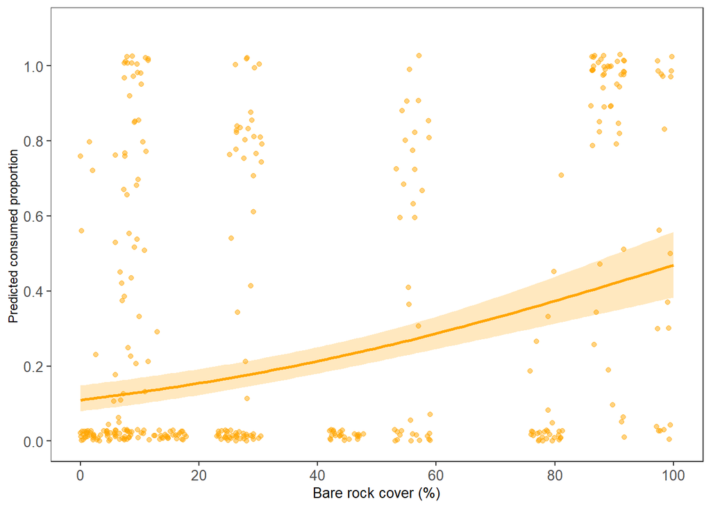

```r
ggplot() +
  geom_ribbon(data = LBR, aes(x = Bare_rock, y = fit, ymin = lwr, ymax = upr), fill = "orange1", alpha = .25) +
  geom_line(data = LBR, aes(x = Bare_rock, y =fit), color =  "orange1", size = 1) +
  geom_jitter(data = Herb_all_stand, aes(x= Bare_rock, y=Consumed_proportion), color = "orange1", width=0.03, height = 0.03, size = 1.5, alpha = 0.5)+
  labs(x = "Bare rock cover (%)", y = "Predicted consumed proportion ")  + Theme1 +
  scale_x_continuous(breaks = c(0, 0.2, 0.4, 0.6, 0.8, 1), labels = c("0", "20", "40", "60", "80", "100"), limits = c(0,1)) +
  scale_y_continuous(limits = c(0,1.1), breaks = seq(0, 1, 0.2)) +
  theme(legend.position = c(0.1, 0.85))
```

```r
ggsave("BareL.jpeg", units="mm", width=110, height=80, dpi=300)
```

4. Dissolved oxygen vs herbivory

[figure not shown]

```r
ggplot() +
  geom_ribbon(data = LOx, aes(x = D_oxygen_mgL, y = fit, ymin = lwr, ymax = upr), fill = "orange1", alpha = .25) +
  geom_line(data = LOx, aes(x = D_oxygen_mgL, y =fit), color =  "orange1", linewidth = 0.6) +
  geom_jitter(data = Herb_all_stand, aes(x= D_oxygen_mgL, y=Consumed_proportion), color = "orange1", width=0.01, height = 0.03, size = 1.3, alpha = 0.5)+
  labs(x = "Dissolved oxygen (mgL)", y = "Predicted n° of consumed squidpops")  + Theme1 +
  scale_x_continuous(breaks = c(0.1082296, 0.384854, 0.66147994, 0.935517247), labels = c("4", "6", "8", "10"), limits = c(0,1))  +
  scale_y_continuous(limits = c(0,1.1), breaks = seq(0, 1, 0.2)) +
  theme(legend.position = c(0.1, 0.85))
```

```r
ggsave("DoxL.jpeg", units="mm", width=110, height=80, dpi=300)
```

## **Part 9**: Supplementary tables

### **9a)** Size estimations summary table

```r
Size_summary <- Size_metadata %>%
  group_by(Species) %>%
  summarise (N_individuals = n(), mean_Size_sp = mean(Size_cm), sd = sd(Size_cm), Max_size = max(Size_cm), Min_size = min(Size_cm))
```

```r
kable(Size_summary)
```

| Species | N_individuals | mean_Size_sp | sd | Max_size | Min_size |
| --- | --- | --- | --- | --- | --- |
| Acanthistius_pictus | 3 | 16.000000 | 1.0000000 | 17 | 15 |
| Anisotremus_scapularis | 4 | 21.250000 | 2.9860788 | 25 | 18 |
| Aplodactylus_punctatus | 54 | 27.944444 | 6.5196848 | 40 | 14 |
| Auchenionchus_critinus | 1 | 12.000000 | NA | 12 | 12 |
| Auchenionchus_sp. | 14 | 19.071429 | 6.0949448 | 32 | 11 |
| Auchenionchus_variolosus | 3 | 28.666667 | 5.6862407 | 35 | 24 |
| Bovichtus_chilensis | 3 | 17.666667 | 9.0184995 | 27 | 9 |
| Calliclinus_geniguttatus | 19 | 10.157895 | 2.3632172 | 14 | 4 |
| Cheilodactylus_variegatus | 125 | 22.560000 | 7.0715240 | 38 | 6 |
| Cheilotrema_fasciatum | 1 | 28.000000 | NA | 28 | 28 |
| Chromis_crusma | 85 | 13.611765 | 4.2457096 | 26 | 5 |
| Congiopodus_peruvianus | 2 | 13.500000 | 0.7071068 | 14 | 13 |
| Girella_laevifrons | 11 | 26.272727 | 7.3087743 | 38 | 15 |
| Graus_nigra | 15 | 25.066667 | 4.9923751 | 37 | 19 |
| Hemilutjanus_macrophthalmos | 2 | 20.000000 | 2.8284271 | 22 | 18 |
| Hepatus_chilensis | 1 | 6.000000 | NA | 6 | 6 |
| Homalaspis_plana | 20 | 9.800000 | 1.9084301 | 12 | 4 |
| Hypsoblennius_sordidus | 5 | 7.800000 | 1.0954451 | 9 | 6 |
| Isacia_conceptionis | 7 | 25.571429 | 2.5071327 | 30 | 22 |
| Labrisomus_philippii | 18 | 28.055556 | 6.9745101 | 38 | 15 |
| Nexilosus_latifrons | 4 | 23.000000 | 5.7154761 | 30 | 17 |
| Paralabrax_humeralis | 14 | 26.571429 | 8.4826908 | 44 | 15 |
| Paralichthys_microps | 4 | 32.500000 | 23.1012265 | 65 | 16 |
| Paraxanthus_barbiger | 12 | 6.250000 | 1.6583124 | 9 | 4 |
| Patagonotothen_brevicauda | 10 | 8.100000 | 1.3703203 | 10 | 6 |
| Pinguipes_chilensis | 81 | 28.370370 | 8.5197483 | 51 | 13 |
| Prolatilus_jugularis | 20 | 24.000000 | 6.9357958 | 39 | 10 |
| Romaleon_setosum | 17 | 8.058824 | 2.2768012 | 12 | 5 |
| Scartichthys_spp. | 176 | 13.670454 | 5.0927884 | 34 | 4 |
| Schroederichthys_chilensis | 3 | 51.666667 | 2.8867513 | 55 | 50 |
| Sebastes_oculatus | 12 | 12.333333 | 7.1137937 | 24 | 4 |
| Semicossyphus_darwini | 6 | 26.500000 | 6.4420494 | 36 | 20 |
| Taliepus_sp. | 27 | 9.444444 | 1.8045526 | 12 | 5 |

```r
write.csv(Size_summary, "Size_summary2.csv")
```

## **Part 10**: R Session Information

In this part, information about the operating system and R packages attached during the production of this document can be found

```r
sessionInfo() %>% pander
```

**R version 4.4.1 (2024-06-14 ucrt)**

**Platform:** x86_64-w64-mingw32/x64

**locale:** *LC_COLLATE=English_Australia.utf8*, *LC_CTYPE=English_Australia.utf8*, *LC_MONETARY=English_Australia.utf8*, *LC_NUMERIC=C* and *LC_TIME=English_Australia.utf8*

**attached base packages:** *stats*, *graphics*, *grDevices*, *utils*, *datasets*, *methods* and *base*

**other attached packages:** *mgcv(v.1.9-1)*, *nlme(v.3.1-164)*, *geosphere(v.1.5-18)*, *MuMIn(v.1.48.4)*, *MASS(v.7.3-60.2)*, *corrplot(v.0.92)*, *car(v.3.1-2)*, *carData(v.3.0-5)*, *knitr(v.1.47)*, *performance(v.0.12.0)*, *ggeffects(v.1.7.0)*, *pander(v.0.6.5)*, *patchwork(v.1.2.0)*, *vegan(v.2.6-6.1)*, *lattice(v.0.22-6)*, *permute(v.0.9-7)*, *summarytools(v.1.0.1)*, *lubridate(v.1.9.3)*, *forcats(v.1.0.0)*, *stringr(v.1.5.1)*, *dplyr(v.1.1.4)*, *purrr(v.1.0.2)*, *readr(v.2.1.5)*, *tidyr(v.1.3.1)*, *tibble(v.3.2.1)*, *ggplot2(v.3.5.1)* and *tidyverse(v.2.0.0)*

**loaded via a namespace (and not attached):** *tidyselect(v.1.2.1)*, *DHARMa(v.0.4.6)*, *farver(v.2.1.2)*, *fastmap(v.1.2.0)*, *digest(v.0.6.35)*, *timechange(v.0.3.0)*, *lifecycle(v.1.0.4)*, *cluster(v.2.1.6)*, *magrittr(v.2.0.3)*, *compiler(v.4.4.1)*, *rlang(v.1.1.4)*, *sass(v.0.4.9)*, *tools(v.4.4.1)*, *utf8(v.1.2.4)*, *yaml(v.2.3.8)*, *labeling(v.0.4.3)*, *sp(v.2.1-4)*, *plyr(v.1.8.9)*, *abind(v.1.4-5)*, *withr(v.3.0.0)*, *grid(v.4.4.1)*, *stats4(v.4.4.1)*, *fansi(v.1.0.6)*, *colorspace(v.2.1-0)*, *scales(v.1.3.0)*, *insight(v.0.20.1)*, *cli(v.3.6.2)*, *crayon(v.1.5.3)*, *rmarkdown(v.2.27)*, *ragg(v.1.3.2)*, *generics(v.0.1.3)*, *rstudioapi(v.0.16.0)*, *reshape2(v.1.4.4)*, *tzdb(v.0.4.0)*, *minqa(v.1.2.7)*, *cachem(v.1.1.0)*, *splines(v.4.4.1)*, *parallel(v.4.4.1)*, *matrixStats(v.1.3.0)*, *base64enc(v.0.1-3)*, *vctrs(v.0.6.5)*, *boot(v.1.3-30)*, *Matrix(v.1.7-0)*, *jsonlite(v.1.8.8)*, *hms(v.1.1.3)*, *rapportools(v.1.1)*, *systemfonts(v.1.1.0)*, *magick(v.2.8.3)*, *jquerylib(v.0.1.4)*, *glue(v.1.7.0)*, *nloptr(v.2.1.0)*, *codetools(v.0.2-20)*, *stringi(v.1.8.4)*, *gtable(v.0.3.5)*, *lme4(v.1.1-35.4)*, *munsell(v.0.5.1)*, *pillar(v.1.9.0)*, *htmltools(v.0.5.8.1)*, *R6(v.2.5.1)*, *textshaping(v.0.4.0)*, *tcltk(v.4.4.1)*, *evaluate(v.0.24.0)*, *highr(v.0.11)*, *backports(v.1.5.0)*, *pryr(v.0.1.6)*, *bslib(v.0.7.0)*, *Rcpp(v.1.0.12)*, *checkmate(v.2.3.1)*, *xfun(v.0.44)* and *pkgconfig(v.2.0.3)*